# M2_991_20251_PAC3_Enunciat-1_FET

[figure not shown]

M2.991 · Aprenentatge automàtic · PAC3

2025-1 · Màster universitari en Ciència de dades (Data science)

Estudis d'informàtica, multimèdia i telecomunicació

# PAC 3: Mètodes supervisats

En aquesta pràctica veurem diferents mètodes supervisats i tractarem d'optimitzar diferents mètriques. Veurem com els diferents models classifiquen les observacions i amb quins obtenim major rendiment. Després aplicarem tot el que hem après fins ara a un dataset nou simulant un cas pràctic real.

1. Exploració d'algorismes supervisats  
   1.1. Càrrega de dades  
   1.2. Anàlisi Exploratòria de Dades  
   1.3. Preparació de dades  
   1.4. K veïns més propers (KNN)  
   1.5. Màquines de suport vectorial (SVM)  
   1.6. Arbres de decisió
2. Comprensió d'algorismes supervisats
3. Implementació del cas pràctic  
   2.1. Càrrega de dades  
   2.2. Anàlisi Exploratòria de Dades  
   2.3. Preprocessament de Dades  
   2.4. Modelització

Consideracions generals:

- La solució plantejada no pot utilitzar mètodes, funcions o paràmetres declarats *deprecated* en futures versions, a excepció de la càrrega de dades com s'indica posteriorment.
- Aquesta PAC ha de realitzar-se de forma **estrictament individual**. Qualsevol indici de còpia serà penalitzat amb un suspens (D) per a totes les parts implicades i la possible avaluació negativa de l'assignatura de forma íntegra.
- És necessari que l'estudiant indiqui **totes les fonts** que ha utilitzat per a la realització de la PAC. En cas contrari, es considerarà que l'estudiant ha comès plagi, sent penalitzat amb un suspens (D) i la possible avaluació negativa de l'assignatura de forma íntegra.

Format del lliurament:

- Alguns exercicis poden suposar diversos minuts d'execució, per la qual cosa el lliurament s'ha de fer en **format notebook** i en **format html**, on es vegi el codi, els resultats i comentaris de cada exercici. Es pot exportar el notebook a HTML des del menú File $\to$ Download as $\to$ HTML.
- Existeix un tipus de cel·la especial per allotjar text. Aquest tipus de cel·la us serà molt útil per respondre a les diferents preguntes teòriques plantejades al llarg de l'activitat. Per canviar el tipus de cel·la a aquest tipus, en el menú: Cell $\to$ Cell Type $\to$ Markdown.

**Nom i cognoms:**

```python
import os
import tqdm
import kagglehub
import umap

import seaborn as sns
import pandas as pd
import numpy as np
import matplotlib.pyplot as plt

from ucimlrepo import fetch_ucirepo
from matplotlib.colors import ListedColormap
from statsmodels.graphics.mosaicplot import mosaic

from sklearn import datasets
from sklearn import tree
from sklearn.svm import SVC
from sklearn.tree import DecisionTreeClassifier, DecisionTreeRegressor
from sklearn.neighbors import KNeighborsClassifier, KNeighborsRegressor
from sklearn.model_selection import GridSearchCV
from sklearn.metrics import accuracy_score, confusion_matrix, f1_score
from sklearn.preprocessing import StandardScaler
from sklearn.model_selection import StratifiedKFold, train_test_split, cross_val_score

%matplotlib inline
```

# 1. Exploració d'algorismes supervisats (4.5 punts)

## 1.1. Càrrega de dades

L'aplicació de tècniques de ciència de dades en la detecció de programari maliciós resulta de gran interès i utilitat, ja que permet analitzar grans volums de dades i descobrir patrons complexos de comportament maliciós que els mètodes tradicionals no aconsegueixen identificar. Els models d'aprenentatge automàtic aporten un valor afegit en facilitar la detecció adaptativa i primerenca d'amenaces en constant evolució, anticipant-se fins i tot a noves variants de ransomware que els mètodes basats en signatures o regles estàtiques no poden predir.

Per això, en aquest exercici treballarem amb un subconjunt del dataset [Ransomware 2024](https://zenodo.org/records/13890887#). Aquest dataset ens permetrà analitzar les diferents característiques del programari que es poden utilitzar per abordar el problema de la detecció automàtica de ransomware. En total, el conjunt de dades ofereix 21.752 mostres etiquetades, amb 10.876 fitxers maliciosos i 10.876 de benignes, abastant 26 famílies distintes de malware amb especial èmfasi en diverses famílies notòries de ransomware.

**Implementació:** Carregueu el conjunt de dades 'Ransomware 2024 Subset.csv' en una variable amb nom 'data' i mostreu:

1. El nombre i nom dels atributs descriptius (variables que podrien ser usades per predir la variable objectiu "Malware").
2. El nombre de files (mostres) del conjunt de dades.
3. Verifiqueu si hi ha o no "missing values" i en quines columnes.

```python
# --- 1) Càrrega el conjunt de dades en un DataFrame ---

# Ruta al fitxer de dades.
data_path = "Ransomware_2024_subset.cvs"

# Carreguem el CSV en un DataFrame que anomenarem 'data'
data = pd.read_csv(data_path)

# Fem una mirada ràpida a les primeres files per assegurar-nos que s'ha carregat bé
data.head()

# --- 2) Nombre de files i columnes ---

# shape retorna (nombre_files, nombre_columnes)
n_files, n_columnes = data.shape

print(f"Nombre de files (mostres): {n_files}")
print(f"Nombre de columnes totals (atributs + objectiu): {n_columnes}")

# Demanem un resum de tipus de dada i valor no-nul
data.info()
# Ara separem atributs descriptius i variable objectiu. Sabem que la columna objectiu es diu Malware:
# --- 3) Nombre i nom dels atributs descriptius ---

target_col = "Malware"  # variable objectiu

# Llista de columnes descriptives: totes les columnes excepte 'Malware'
atributs_descriptius = [col for col in data.columns if col != target_col]

print("Nombre d'atributs descriptius:", len(atributs_descriptius))
print("Nom dels atributs descriptius:")
for col in atributs_descriptius:
    print(f" - {col}")
# Finalment, mirem els missing values:
# --- 4) Comprovació de valors perduts (missing values) ---

# isna() crea una matriu booleana; sum() compta quants NaN hi ha a cada columna
missing_per_col = data.isna().sum()

print("Nombre de valors perduts per columna:")
print(missing_per_col)

# Verifiquem només les columnes que tenen algun valor perdut:
cols_amb_missing = missing_per_col[missing_per_col > 0]

if cols_amb_missing.empty:
    print("\nConclusió: No hi ha valors perduts (NaN) al conjunt de dades.")
else:
    print("\nColumnes amb valors perduts:")
    print(cols_amb_missing)
```

```
Nombre de files (mostres): 21752
Nombre de columnes totals (atributs + objectiu): 23
<class 'pandas.core.frame.DataFrame'>
RangeIndex: 21752 entries, 0 to 21751
Data columns (total 23 columns):
 #   Column                     Non-Null Count  Dtype
---  ------                     --------------  -----
 0   PEType                     21752 non-null  object
 1   bytes_on_last_page         21752 non-null  object
 2   max_extra_paragraphs       21752 non-null  object
 3   init_sp_value              21752 non-null  object
 4   SizeofStackReserve         21752 non-null  object
 5   LoaderFlags                21752 non-null  object
 6   text_PointerToRelocations  21752 non-null  object
 7   registry_read              21752 non-null  float64
 8   registry_write             21752 non-null  float64
 9   registry_delete            21752 non-null  float64
 10  network_dns                21752 non-null  float64
 11  network_http               21752 non-null  float64
 12  network_connections        21752 non-null  float64
 13  processes_suspicious       21752 non-null  float64
 14  processes_monitored        21752 non-null  float64
 15  total_procsses             21752 non-null  float64
 16  files_malicious            21752 non-null  float64
 17  files_suspicious           21752 non-null  float64
 18  files_text                 21752 non-null  float64
 19  files_unknown              21752 non-null  float64
 20  dlls_calls                 21752 non-null  float64
 21  apis                       21752 non-null  float64
 22  Malware                    21752 non-null  int64
dtypes: float64(15), int64(1), object(7)
memory usage: 3.8+ MB
Nombre d'atributs descriptius: 22
Nom dels atributs descriptius:
 - PEType
 - bytes_on_last_page
 - max_extra_paragraphs
 - init_sp_value
 - SizeofStackReserve
 - LoaderFlags
```

[output cut: 28 more lines]

```
network_http                 0
network_connections          0
processes_suspicious         0
processes_monitored          0
total_procsses               0
files_malicious              0
files_suspicious             0
files_text                   0
files_unknown                0
dlls_calls                   0
apis                         0
Malware                      0
dtype: int64

Conclusió: No hi ha valors perduts (NaN) al conjunt de dades.
```

## 1.2. Anàlisi Exploratòria de Dades (EDA) (0.75 punts)

En aquest apartat realitzarem una anàlisi exploratòria de dades centrada en analitzar patrons i relacions entre les diverses variables.

**Implementació:** Calculeu la correlació de les variables numèriques i mostreu un mapa de calor amb el resultat.

```
Variables numèriques:
 - registry_read
 - registry_write
 - registry_delete
 - network_dns
 - network_http
 - network_connections
 - processes_suspicious
 - processes_monitored
 - total_procsses
 - files_malicious
 - files_suspicious
 - files_text
 - files_unknown
 - dlls_calls
 - apis
 - Malware
```

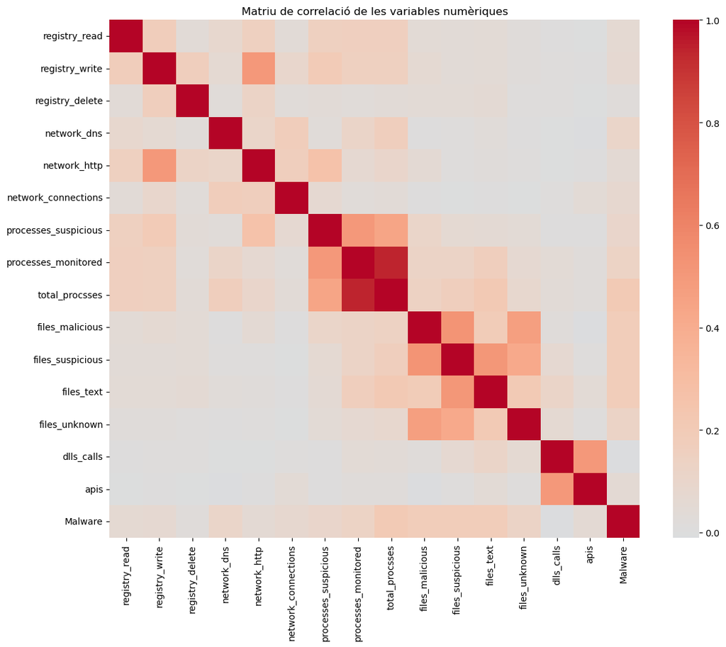

```python
# --- 1. Seleccionem només les variables numèriques ---

# Ens quedem amb les columnes de tipus numèric (int, float, bool)
num_cols = data.select_dtypes(include=["number", "bool"]).columns.tolist()

print("Variables numèriques:")
for col in num_cols:
    print(f" - {col}")

# --- 2. Calculem la matriu de correlació ---

corr_matrix = data[num_cols].corr()  # Pearson per defecte

# --- 3. Representem la matriu de correlació amb un mapa de calor ---

plt.figure(figsize=(12, 10))
sns.heatmap(
    corr_matrix,
    annot=False,       # podem posar True si volem veure els valors numèrics
    cmap="coolwarm",   # paleta habitual per veure correlacions positives/negatives
    center=0
)
plt.title("Matriu de correlació de les variables numèriques")
plt.tight_layout()
plt.show()
```

**Implementació:** Seleccioneu quatre característiques numèriques basant-vos en el resultat obtingut en l'apartat anterior i representeu gràficament les relacions entre aquestes variables (scatterplots). Diferencieu amb colors diferents les diferents classes.

La finalitat és poder observar i analitzar les correlacions de manera gràfica entre algunes de les variables.

Suggeriment: podeu usar la funció "pairplot" de la llibreria 'seaborn' amb el paràmetre "hue".

```
Correlació absoluta amb la variable objectiu:
Malware                 1.000000
total_procsses          0.206377
files_text              0.185967
files_malicious         0.181668
files_suspicious        0.179985
processes_monitored     0.133086
files_unknown           0.127705
network_dns             0.110005
processes_suspicious    0.100080
network_connections     0.077697
registry_write          0.069566
registry_read           0.060245
network_http            0.055021
apis                    0.051610
registry_delete         0.020985
dlls_calls              0.009951
Name: Malware, dtype: float64

Quatre variables seleccionades per al pairplot:
 - total_procsses
 - files_text
 - files_malicious
 - files_suspicious
```

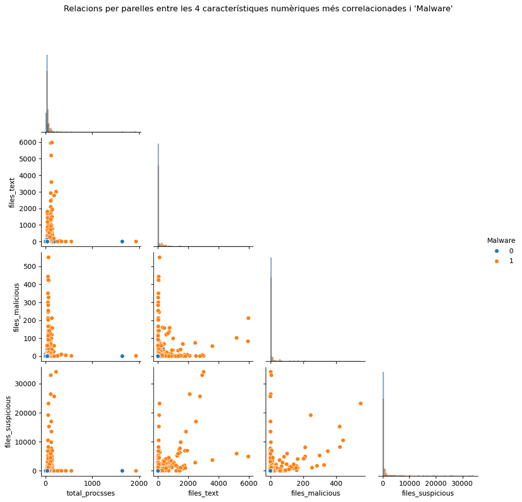

```python
target_col = "Malware"

# --- 1. Correlació de les variables numèriques amb la variable objectiu ---

# Ens assegurem que 'Malware' està entre les numèriques
num_cols = data.select_dtypes(include=["number", "bool"]).columns.tolist()

if target_col not in num_cols:
    raise ValueError(f"La columna objectiu {target_col} no és numèrica!")

# Correlació de totes les numèriques amb la variable 'Malware'
corr_with_target = data[num_cols].corr()[target_col].abs().sort_values(ascending=False)

print("Correlació absoluta amb la variable objectiu:")
print(corr_with_target)

# Ens quedem amb les 4 primeres variables explicatives (ignorant 'Malware')
top_features = [col for col in corr_with_target.index if col != target_col][:4]

print("\nQuatre variables seleccionades per al pairplot:")
for col in top_features:
    print(f" - {col}")

# --- 2. Fem un pairplot amb aquestes variables + la variable objectiu com a 'hue' ---

# Per fer el gràfic més lleuger, treballem amb una mostra aleatòria
sample_size = 2000  # ajustem si cal
if len(data) > sample_size:
    data_sample = data.sample(n=sample_size, random_state=42)
else:
    data_sample = data

sns.pairplot(
    data_sample[top_features + [target_col]],
    hue=target_col,      # color per classe (0/1)
    diag_kind="hist",
    corner=True          # només triangle inferior, (és més net)
)
plt.suptitle("Relacions per parelles entre les 4 característiques numèriques més correlacionades i 'Malware'", y=1.02)
plt.show()
```

**Implementació:** Mostreu un gràfic de mosaic per a cadascuna de les variables categòriques, de forma que en cada gràfic es visualitzi la relació entre una variable categòrica i la variable objectiu (Malware).

Suggeriment: podeu usar la funció "mosaic" de la llibreria 'statsmodels'.

```
Variables categòriques trobades:
 - PEType
 - bytes_on_last_page
 - max_extra_paragraphs
 - init_sp_value
 - SizeofStackReserve
 - LoaderFlags
 - text_PointerToRelocations
```

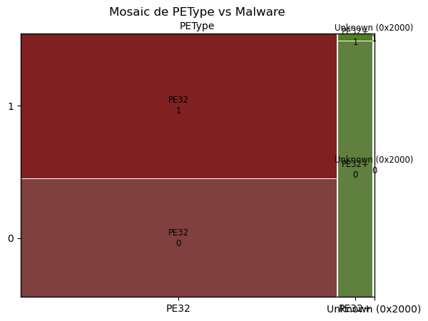

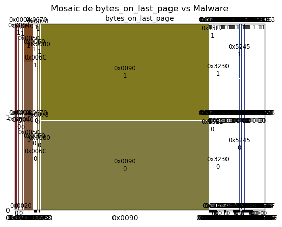

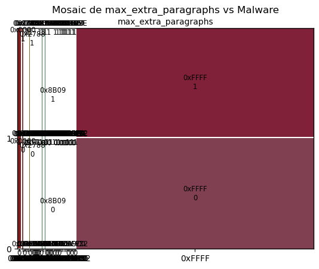

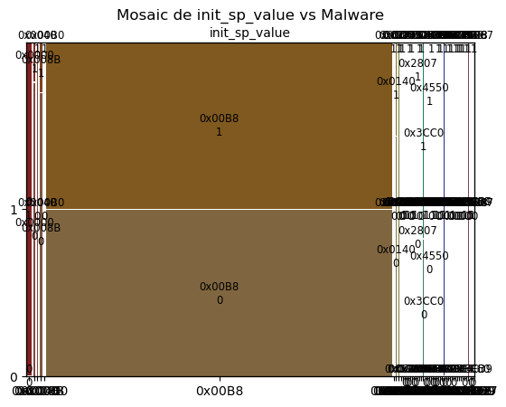

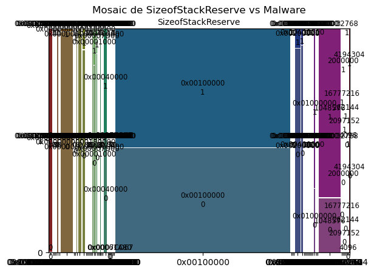

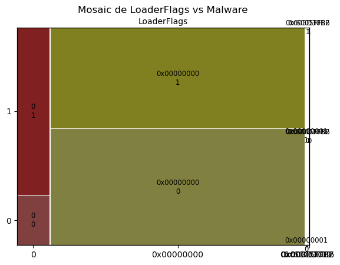

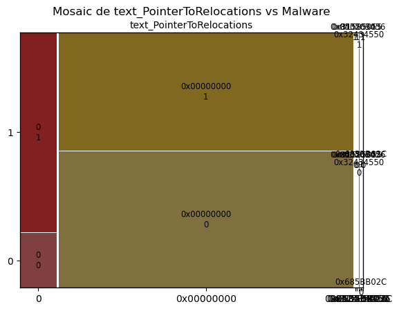

```python
# --- 1. Identifiquem les variables categòriques ---

# Considerem object i category com a categòriques
cat_cols = data.select_dtypes(include=["object", "category"]).columns.tolist()

# Ens assegurem de no incloure la variable objectiu en el cas fos categòrica
cat_cols = [col for col in cat_cols if col != target_col]

print("Variables categòriques trobades:")
for col in cat_cols:
    print(f" - {col}")

# --- 2. Funció per dibuixar un mosaic per a una columna categòrica vs 'Malware' ---

def mosaic_for_col(df, cat_col, target_col="Malware"):
    """
    Dibuixa un gràfic de mosaic per a la relació entre 'cat_col' i 'target_col'.
    """
    # Taula de contingència: files = categories de cat_col, columnes = valors de Malware
    ct = pd.crosstab(df[cat_col], df[target_col])

    # mosaic espera un diccionari o una sèrie amb índex múltiple
    plt.figure(figsize=(6, 4))
    mosaic(ct.stack(), title=f"Mosaic de {cat_col} vs {target_col}")
    plt.xlabel(cat_col)
    plt.ylabel("Proporció")
    plt.show()

# --- 3. Generem un mosaic per a cada variable categòrica ---

for col in cat_cols:
    mosaic_for_col(data, col, target_col=target_col)
```

**Anàlisi:** Comenteu els resultats de l'anàlisi exploratòria

Anàlisi exploratòria

El conjunt de dades té 21.752 mostres, 22 atributs descriptius i 1 objectiu (Malware). No hi ha valors perduts, així que no cal imputació.

Les variables numèriques relacionades amb processos i fitxers (total_processes, files_text, files_malicious, files_suspicious, processes_monitored, etc.) són les que mostren correlació més alta amb Malware. En el pairplot es veu clar: quan aquests comptadors són alts, gairebé sempre correspon a fitxers maliciosos.

Hi ha correlacions moderades entre les pròpies variables numèriques (per exemple, entre diferents tipus de fitxers i processos), cosa que indica certa redundància però també un patró coherent d’“activitat elevada = comportament sospitós”.

En resum, l’EDA suggereix que la detecció de ransomware en aquest dataset es basa sobretot en patrons d’activitat elevada de processos i fitxers, mentre que la informació categòrica té un paper més secundari.

## 1.3. Preparació de dades

Per a poder visualitzar els resultats de cada algorisme supervisat, reduirem el dataset anterior a dues dimensions.

**NOTA**: Aquest exercici s'ha plantejat des d'un punt de vista didàctic, per la qual cosa **utilitzarem en tot l'exercici el dataset reduït a dues dimensions** amb l'objectiu de visualitzar les fronteres de decisió dels models. Aplicar directament reducció de la dimensionalitat no té per què ser la millor tècnica o aproximació per abordar el problema d'aprenentatge supervisat. No obstant això, ens servirà per visualitzar i aprofundir en l'enteniment sobre les fronteres que aprenen els diferents models.

```python
labels = ['Benign', 'Malware']
n_classes = len(labels)
num_columns = data._get_numeric_data().columns
categorical_columns = list(set(data.columns) - set(num_columns))

cat_df = pd.get_dummies(data[categorical_columns], dtype=int)
data = pd.concat([data, cat_df], axis=1, join="inner")
data = data.drop(columns=categorical_columns)

X = data.drop(columns=['Malware'])
y = data['Malware']

X_train, X_test, y_train, y_test = train_test_split(X, y, test_size=0.2, random_state=24)
```

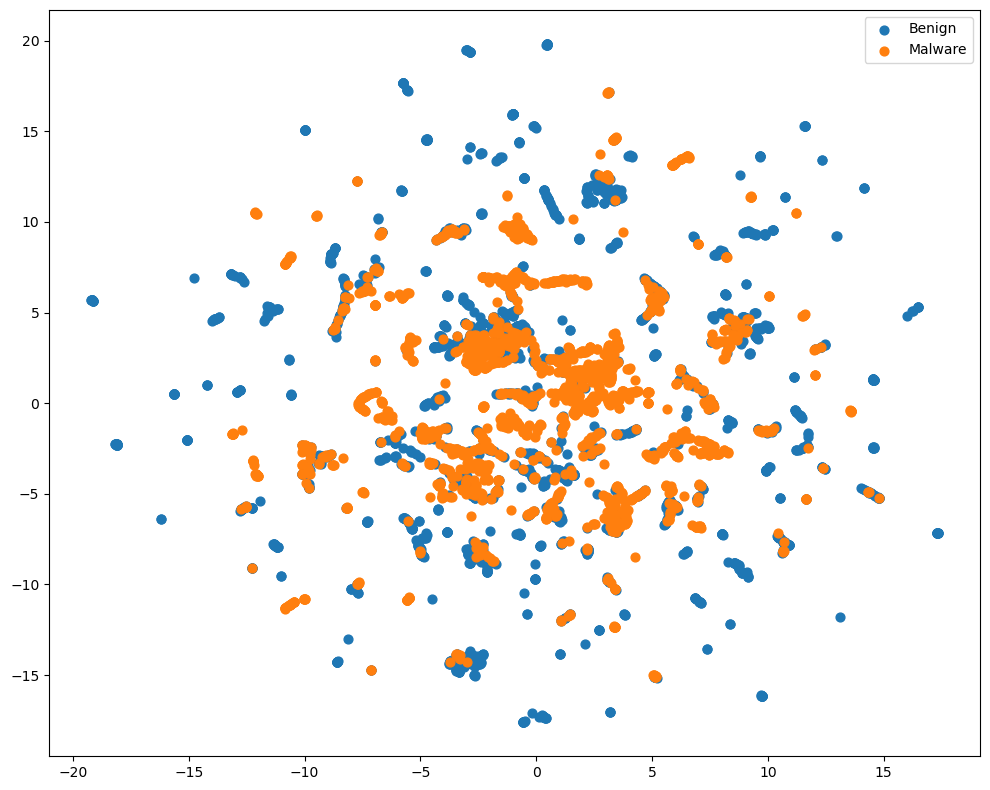

```python
scaler = StandardScaler()
X_train = scaler.fit_transform(X_train)
X_test = scaler.transform(X_test)

model = umap.UMAP(n_components=2, n_jobs=1)
model.fit(X_train)

X_train_projection = model.transform(X_train)
X_test_projection = model.transform(X_test)

fig, ax = plt.subplots(1, 1, figsize=(10, 8))
for i in range(n_classes):
    ax.scatter(X_test_projection[y_test == i,0], X_test_projection[y_test == i,1], s=40, marker='o', label=labels[i])

plt.legend()
plt.tight_layout()
plt.show()
```

Al llarg de l'exercici aprendrem a veure gràficament les fronteres de decisió que ens retornen els diferents models. Per a això utilitzarem la funció definida a continuació, que segueix els següents passos:

1. Crear una meshgrid amb els valors mínim i màxim de 'x' i 'y'.
2. Predir el classificador amb els valors de la meshgrid.
3. Fer un reshape de les dades per tenir el format corresponent.

Un cop fet això, ja podem fer el gràfic de les fronteres de decisió i afegir els punts reals. Així veurem les àrees que el model considera que són d'una classe i les que considera que són d'una altra. En posar a sobre els punts veurem si els classifica correctament a l'àrea que els correspon.

```python
# Define the function that will visualize the decision boundary
def plot_decision_boundaries(model, X_test_projection, y_test):

    # Create the meshgrid with the minimum and maximum values of the x and y axes
    x_min, x_max = X_test_projection[:, 0].min() - 1, X_test_projection[:, 0].max() + 1
    y_min, y_max = X_test_projection[:, 1].min() - 1, X_test_projection[:, 1].max() + 1

    xx, yy = np.meshgrid(np.arange(x_min, x_max, 0.05),
                         np.arange(y_min, y_max, 0.05))

    # Prediction by using all values of the meshgrid
    Z = model.predict(np.c_[xx.ravel(), yy.ravel()])

    # Define the colors (one for each class)
    cmap_light = ListedColormap(['gainsboro','lightgreen','peachpuff','lightcyan', 'pink'])
    cmap_bold = ['g','sandybrown','c','palevioletred']

    # Draw the borders
    Z = Z.reshape(xx.shape)
    plt.figure(figsize=(20,10))
    plt.pcolormesh(xx, yy, Z, cmap=cmap_light)

    # Draw the points
    for i in range(n_classes):
        plt.scatter(X_test_projection[y_test == i,0], X_test_projection[y_test == i,1],
                    s=40, marker='o', label=labels[i], c=cmap_bold[i])
    plt.legend(loc='best')
    plt.xlim(xx.min(), xx.max())
    plt.ylim(yy.min(), yy.max())
    plt.show()
```

## 1.4. KNN (1.25 punts)

En aquest punt, entendràs el funcionament de l'algorisme KNN (K-Nearest-Neighbor), que es basa en la proximitat dels punts de dades en un espai de característiques. Analitzaràs els seus avantatges i desavantatges, i comprendràs com els paràmetres que el componen influeixen en el seu comportament.

KNN és un algorisme de tipus supervisat basat en instància. Això significa:

- Supervisat: El teu conjunt de dades d'entrenament està etiquetat amb la classe o resultat esperat.
- Basat en instància (*Lazy Learning*): L'algorisme no aprèn explícitament un model, com en la Regressió Logística o els arbres de decisió. En canvi, memoritza les instàncies d'entrenament i les utilitza com a "coneixement" en la fase de predicció.

Per entendre com funciona KNN, segueix aquests passos:

1. Calcula la distància entre l'ítem a classificar i els altres ítems del dataset d'entrenament.
2. Selecciona els "k" elements més propers, és a dir, aquells amb la menor distància, segons el tipus de distància que utilitzis (euclidiana, cosinus, manhattan, etc.).
3. Realitza una "votació de majoria" entre els k punts seleccionats: la classe que predomini en aquests punts decidirà la classificació final de l'ítem analitzat.

**Implementació:**

Realitza els següents passos amb el dataset d'entrenament (*train*):

1. Entrena un classificador KNN amb l'hiperparàmetre `n_neighbors=2` usant el classificador `KNeighborsClassifier` de `sklearn`.
2. Calcula l'*accuracy* (precisió) del model tant en les dades de *train* com de *test*.
3. Calcula la matriu de confusió utilitzant les dades de *test*.
4. Representa gràficament la frontera de decisió amb les dades de *test*.

Si en entrenar el classificador apareix un avís (warning) i desitges ignorar-lo, executa el següent codi abans de l'entrenament:

`import warnings` `warnings.filterwarnings('ignore', message='^.*will change.*$', category=FutureWarning)`"

Això et permetrà avaluar l'efectivitat del model KNN amb `n_neighbors=2` en el teu conjunt de dades, i entendre com es comporta en termes de classificació i separació de classes.

```
Accuracy KNN (k=2) - train: 0.9370
Accuracy KNN (k=2) - test : 0.8600
```

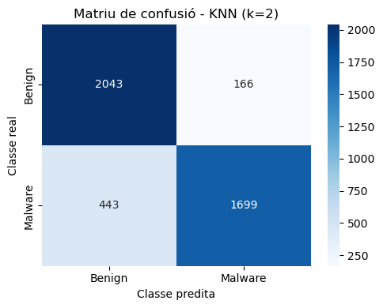

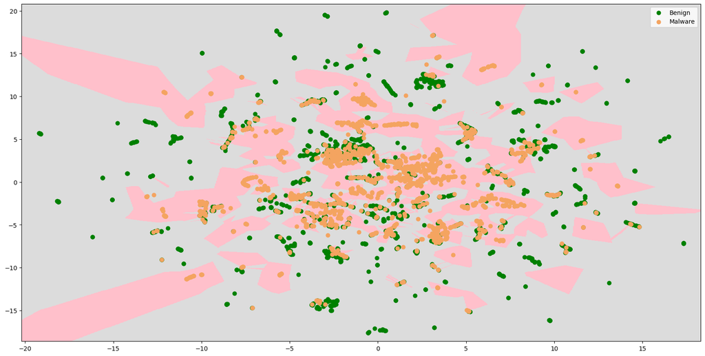

```python
import warnings

# ignorem  un Future Warning concret
warnings.filterwarnings('ignore', message='^.*will change.*$', category=FutureWarning)

# 1) Definim i entrenem el KNN amb k = 2 sobre la projecció UMAP (2D)
knn2 = KNeighborsClassifier(n_neighbors=2)
knn2.fit(X_train_projection, y_train)

# 2) Prediccions sobre train i test
y_train_pred_knn2 = knn2.predict(X_train_projection)
y_test_pred_knn2 = knn2.predict(X_test_projection)

# 3) Accuracy en train i test
acc_train_knn2 = accuracy_score(y_train, y_train_pred_knn2)
acc_test_knn2 = accuracy_score(y_test, y_test_pred_knn2)

print(f"Accuracy KNN (k=2) - train: {acc_train_knn2:.4f}")
print(f"Accuracy KNN (k=2) - test : {acc_test_knn2:.4f}")

# 4) Matriu de confusió en test
cm_knn2 = confusion_matrix(y_test, y_test_pred_knn2)

plt.figure(figsize=(5, 4))
sns.heatmap(cm_knn2,
            annot=True, fmt='d',
            cmap='Blues',
            xticklabels=labels,
            yticklabels=labels)
plt.xlabel('Classe predita')
plt.ylabel('Classe real')
plt.title('Matriu de confusió - KNN (k=2)')
plt.tight_layout()
plt.show()

# 5) Frontera de decisió
plot_decision_boundaries(knn2, X_test_projection, y_test)
```

En el model que has entrenat, has fixat el paràmetre `n_neighbors` de forma arbitrària. No obstant això, és possible que amb un altre valor obtinguis una millor predicció. Per trobar el valor òptim dels paràmetres d'un model (*hyperparameter tunning*), sovint s'utilitza una cerca de reixeta (*grid search*). Això implica entrenar un model per a cada combinació possible d'hiperparàmetres i avaluar-lo mitjançant validació creuada (*cross validation*) amb 5 particions estratificades. Després, seleccionaràs la combinació d'hiperparàmetres que hagi obtingut els millors resultats.

En aquest cas, et centraràs a optimitzar un sol hiperparàmetre:

- 𝑘: el nombre de veïns que es consideren per classificar un nou exemple. Has de provar amb tots els valors entre 1 i 20.

Realitza aquest procés per identificar el nombre òptim de veïns, la qual cosa et permetrà millorar la precisió de les teves prediccions amb el model KNN.

**Implementació:**

Per calcular el valor òptim de l'hiperparàmetre *k* (`n_neighbors`), has de realitzar una cerca de reixeta amb validació creuada. Aquest procés t'ajudarà a trobar el valor òptim de *k*. Per a cada valor, calcula la seva mitjana i la desviació estàndard. Després, implementa un *lineplot* per visualitzar la precisió segons els diferents valors de l'hiperparàmetre.

Utilitza el mòdul `GridSearchCV` de `sklearn` per calcular el millor hiperparàmetre. Per a la visualització del *lineplot*, empra la llibreria `Seaborn`.

Aquests passos et permetran identificar de manera efectiva i visual el valor de *k* que maximitza la precisió del teu model KNN."

```
Millor conjunt de paràmetres: {'n_neighbors': 5}
Millor accuracy de cross-validation: 0.8896
```

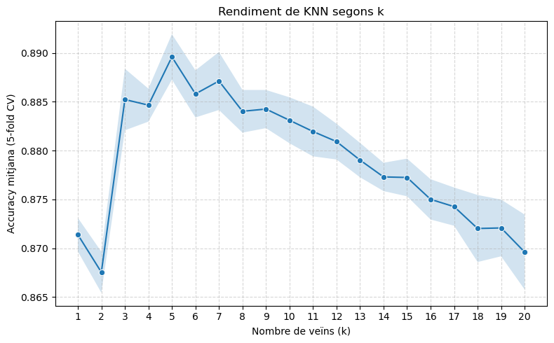

```python
# 1) Definim el model base i la graella de paràmetres
knn = KNeighborsClassifier()

param_grid_knn = {
    'n_neighbors': list(range(1, 21))  # k = 1..20
}

# 2) Definim l'esquema de validació creuada estratificada (5 folds)
cv = StratifiedKFold(n_splits=5, shuffle=True, random_state=24)

# 3) Configurem el GridSearchCV
grid_knn = GridSearchCV(
    estimator=knn,
    param_grid=param_grid_knn,
    scoring='accuracy',
    cv=cv,
    n_jobs=-1,
    return_train_score=True
)

# 4) Ajustem el grid sobre les dades d'entrenament en 2D
grid_knn.fit(X_train_projection, y_train)

print("Millor conjunt de paràmetres:", grid_knn.best_params_)
print(f"Millor accuracy de cross-validation: {grid_knn.best_score_:.4f}")

# 5) Resultats detallats del grid
results_knn = pd.DataFrame(grid_knn.cv_results_)

# Ens assegurem que k és enter
results_knn['param_n_neighbors'] = results_knn['param_n_neighbors'].astype(int)

# Ordenem per k
results_knn = results_knn.sort_values('param_n_neighbors')

# 6) Fem un lineplot: k vs mean_test_score
plt.figure(figsize=(8, 5))
sns.lineplot(
    data=results_knn,
    x='param_n_neighbors',
    y='mean_test_score',
    marker='o'
)

# Afegim banda d'incertesa ± des. estàndard
plt.fill_between(
    results_knn['param_n_neighbors'],
    results_knn['mean_test_score'] - results_knn['std_test_score'],
    results_knn['mean_test_score'] + results_knn['std_test_score'],
    alpha=0.2
)

plt.xlabel("Nombre de veïns (k)")
plt.ylabel("Accuracy mitjana (5-fold CV)")
plt.title("Rendiment de KNN segons k")
plt.xticks(results_knn['param_n_neighbors'])
plt.grid(True, linestyle='--', alpha=0.5)
plt.tight_layout()
plt.show()
```

**Implementació:**

Segueix aquests passos amb el dataset d'entrenament (*train*):

1. Entrena un classificador KNN utilitzant el millor hiperparàmetre que hagis trobat.
2. Calcula l'*accuracy* (precisió) del model tant en les dades de *train* com de *test*.
3. Calcula la matriu de confusió utilitzant les dades de *test*.
4. Representa gràficament la frontera de decisió amb les dades de *test*.

Aquest procés et permetrà veure com l'hiperparàmetre òptim que has identificat millora l'efectivitat del teu model KNN en la classificació de les dades.

```
Millor k trobat: 5
Accuracy KNN (k=5) - train: 0.9199
Accuracy KNN (k=5) - test : 0.8770
```

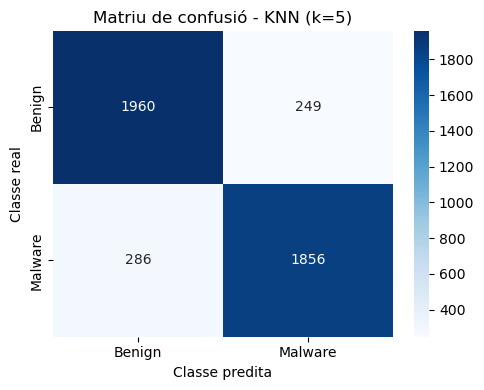

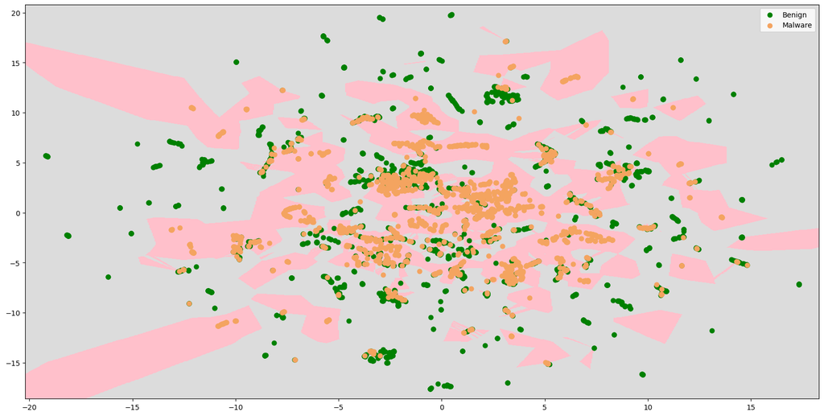

```python
best_k = grid_knn.best_params_['n_neighbors']
print("Millor k trobat:", best_k)

# 1) Entrenem un nou KNN amb k òptim sobre tot X_train_projection
knn_best = KNeighborsClassifier(n_neighbors=best_k)
knn_best.fit(X_train_projection, y_train)

# 2) Prediccions
y_train_pred_knn_best = knn_best.predict(X_train_projection)
y_test_pred_knn_best = knn_best.predict(X_test_projection)

# 3) Accuracy train / test
acc_train_knn_best = accuracy_score(y_train, y_train_pred_knn_best)
acc_test_knn_best = accuracy_score(y_test, y_test_pred_knn_best)

print(f"Accuracy KNN (k={best_k}) - train: {acc_train_knn_best:.4f}")
print(f"Accuracy KNN (k={best_k}) - test : {acc_test_knn_best:.4f}")

# 4) Matriu de confusió
cm_knn_best = confusion_matrix(y_test, y_test_pred_knn_best)

plt.figure(figsize=(5, 4))
sns.heatmap(cm_knn_best,
            annot=True, fmt='d',
            cmap='Blues',
            xticklabels=labels,
            yticklabels=labels)
plt.xlabel('Classe predita')
plt.ylabel('Classe real')
plt.title(f'Matriu de confusió - KNN (k={best_k})')
plt.tight_layout()
plt.show()

# 5) Frontera de decisió amb el millor k
plot_decision_boundaries(knn_best, X_test_projection, y_test)
```

**Anàlisi:**

1. Comenta els resultats obtinguts en la cerca del millor hiperparàmetre. Reflexiona sobre com va variar el rendiment del model amb els diferents valors de `n_neighbors`.
2. Analitza com es visualitza gràficament el canvi del valor de `n_neighbors`. Observes alguna tendència o patró clar? És coherent aquesta diferència entre els dos gràfics en canviar el paràmetre?
3. Examina les fronteres de decisió que has generat. La forma d'aquestes fronteres té sentit donat l'algorisme KNN utilitzat? Pensa en com l'elecció del nombre de veïns influeix en la forma de la frontera.
4. Avalua les prediccions realitzades sobre el conjunt de test. Observa la seva precisió i com es distribueixen en relació amb les fronteres de decisió. Són aquestes prediccions consistents amb el que observes en les fronteres de decisió?

Aquesta anàlisi t'ajudarà a comprendre l'eficàcia del model KNN amb diferents configuracions de `n_neighbors` i el seu impacte en la classificació de les dades."

1. Cerca del millor k: Veiem que l’accuracy de CV puja ràpidament en passar de k=1 a k≈5, on s’assoleix el màxim (~0.89), i a partir d’aquí decreix de forma suau quan augmentem k. Això és coherent amb la teoria de KNN: amb k molt petit el model sobreajusta (baixa capacitat de generalització) i amb k massa gran la frontera es torna massa suau i augmenta el biaix.
2. Canvi gràfic segons k: Al lineplot es veu clar aquest “pic” al voltant de k=5–6 i una caiguda progressiva per k>8. En passar de k=2 a k=5, la frontera de decisió es fa visualment més suau i amb menys “illots” petits: la superfície rosa està menys trencada. Aquesta diferència és coherent amb l’efecte d’incrementar k, que tendeix a agrupar més punts i a filtrar soroll local.
3. Forma de les fronteres de decisió: Les fronteres són molt irregulars per k=2, amb zones estretes i llengües que s’endinsen en l’altra classe; això té sentit perquè cada punt es decideix bàsicament pels veïns immediats. Amb k=5, les regions són més amples i contínues, tal com s’espera d’un KNN amb més veïns: cada decisió reflecteix una mitjana local de més exemples i la frontera es torna menys accidentada.
4. Prediccions sobre el conjunt de test: Tant amb k=2 com amb k=5 l’accuracy en test és alta (~0.86–0.88), però amb k=5 millora lleugerament i es redueixen clarament els falsos negatius (443 → 286), tot i augmentar els falsos positius. Els errors es concentren visualment en zones on les dues classes es barregen a la projecció UMAP, just al voltant de la frontera de decisió, de manera que el patró d’errors és coherent amb la forma de les fronteres generades pel KNN.

## 1.5. SVM (1.25 punts)

En aquesta secció, exploraràs les Màquines de Vectors de Suport (SVM), que es basen en el concepte del *Maximal Margin Classifier* i l'hiperplà.

Un hiperplà en un espai p-dimensional es defineix com un subespai pla i afí de dimensions p-1. En dues dimensions, és una recta; en tres, un pla convencional. Per a dimensions majors a tres, tot i que no és intuïtiu visualitzar-lo, el concepte es manté.

Quan els casos són perfectament separables de manera lineal, sorgeixen infinits possibles hiperplans. Per seleccionar el classificador òptim, utilitza el concepte de *maximal margin hyperplane*, l'hiperplà que es troba més allunyat de totes les observacions d'entrenament. Aquest es defineix calculant la distància perpendicular mínima (marge) de les observacions a un hiperplà. L'hiperplà òptim és aquell que maximitza aquest marge.

En el procés d'optimització, has de tenir en compte que només les observacions al marge o que el violen (vectors suport) influeixen en l'hiperplà. Aquests vectors suport són els que defineixen el classificador.

#### Els *kernels* en SVM

En situacions on no pots trobar un hiperplà que separi dues classes, és a dir, quan les classes no són linealment separables, pots utilitzar el truc del nucli (*kernel trick*). Aquest mètode et permet treballar en una dimensió nova on és possible trobar un hiperplà per separar les classes.

Igual que amb el KNN, les SVM també depenen de diversos hiperparàmetres. En aquest cas, t'enfocaràs en optimitzar dos hiperparàmetres:

1. **C**: la regularització, que és el valor de penalització dels errors en la classificació. Aquest valor indica el compromís entre obtenir l'hiperplà amb el marge més gran possible i classificar correctament el màxim nombre d'exemples. Has de provar els següents valors: 0.01, 0.1, 1, 10, 50, 100 i 200.
2. **Gamma**: un coeficient que multiplica la distància entre dos punts en el kernel radial. En termes simples, com més petit sigui gamma, més influència tindran dos punts propers. Has de provar els valors: 0.001, 0.01, 0.1, 1 i 10.

Per validar el rendiment de l'algorisme amb cada combinació d'hiperparàmetres, utilitza la validació creuada (*cross-validation*) amb 5 particions estratificades."

**Implementació:**

1. Calcula el valor òptim dels hiperparàmetres *C* i *gamma* utilitzant una cerca de reixeta amb validació creuada. Aquest procés t'ajudarà a trobar els valors òptims.
2. Per a cada combinació de valors, calcula la seva mitjana i la desviació estàndard.
3. Fes un *heatmap* per visualitzar la precisió segons els diferents valors dels hiperparàmetres.

Utilitza el mòdul `GridSearchCV` de `sklearn` per calcular els millors hiperparàmetres amb el classificador SVC (de `SVM` de `sklearn`). Per a la visualització del *heatmap*, empra la llibreria `Seaborn`.

Aquests passos et permetran identificar de manera efectiva i visual els valors de *C* i *gamma* que maximitzen la precisió del teu model SVM.

```
Millors hiperparàmetres SVM: {'C': 50, 'gamma': 10}
Millor accuracy de cross-validation: 0.8918
```

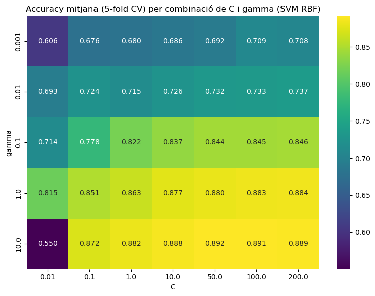

```python
# 1) Definim el model base (SVC amb kernel RBF)
svc = SVC(kernel='rbf')

# 2) Definim la graella d'hiperparàmetres
param_grid_svm = {
    'C': [0.01, 0.1, 1, 10, 50, 100, 200],
    'gamma': [0.001, 0.01, 0.1, 1, 10]
}

# 3) GridSearchCV amb la mateixa CV estratificada (5 folds)
grid_svm = GridSearchCV(
    estimator=svc,
    param_grid=param_grid_svm,
    scoring='accuracy',
    cv=cv,              # el StratifiedKFold que hem definit abans
    n_jobs=-1,
    return_train_score=True
)

grid_svm.fit(X_train_projection, y_train)

print("Millors hiperparàmetres SVM:", grid_svm.best_params_)
print(f"Millor accuracy de cross-validation: {grid_svm.best_score_:.4f}")

# 4) Resultats detallats
results_svm = pd.DataFrame(grid_svm.cv_results_)

# Ens assegurem que C i gamma són numèrics
results_svm['param_C'] = results_svm['param_C'].astype(float)
results_svm['param_gamma'] = results_svm['param_gamma'].astype(float)

# 5) Taula pivot: files = gamma, columnes = C
pivot_svm = results_svm.pivot(
    index='param_gamma',
    columns='param_C',
    values='mean_test_score'
)

plt.figure(figsize=(8, 6))
sns.heatmap(
    pivot_svm,
    annot=True, fmt=".3f",
    cmap='viridis'
)
plt.xlabel("C")
plt.ylabel("gamma")
plt.title("Accuracy mitjana (5-fold CV) per combinació de C i gamma (SVM RBF)")
plt.tight_layout()
plt.show()
```

**Implementació:**

Realitza els següents passos amb el dataset d'entrenament (*train*):

1. Entrena un model SVM utilitzant la millor combinació de paràmetres que hagis trobat.
2. Calcula l'*accuracy* (precisió) del model tant en les dades de *train* com de *test*.
3. Calcula la matriu de confusió utilitzant les dades de *test*.
4. Representa gràficament la frontera de decisió amb les dades de *test*.

Aquest procés et permetrà veure com la millor combinació de paràmetres millora l'efectivitat del teu model SVM en la classificació de les dades.

```
Millor C: 50
Millor gamma: 10
Accuracy SVM (C=50, gamma=10) - train: 0.9160
Accuracy SVM (C=50, gamma=10) - test : 0.8821
```

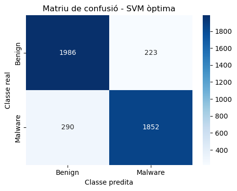

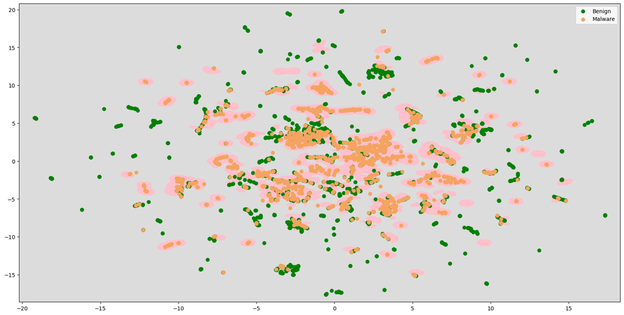

```python
best_C = grid_svm.best_params_['C']
best_gamma = grid_svm.best_params_['gamma']
print("Millor C:", best_C)
print("Millor gamma:", best_gamma)

# 1) Entrenem un nou model SVM amb els millors paràmetres
svm_best = SVC(kernel='rbf', C=best_C, gamma=best_gamma)
svm_best.fit(X_train_projection, y_train)

# 2) Prediccions
y_train_pred_svm = svm_best.predict(X_train_projection)
y_test_pred_svm = svm_best.predict(X_test_projection)

# 3) Accuracy train / test
acc_train_svm = accuracy_score(y_train, y_train_pred_svm)
acc_test_svm = accuracy_score(y_test, y_test_pred_svm)

print(f"Accuracy SVM (C={best_C}, gamma={best_gamma}) - train: {acc_train_svm:.4f}")
print(f"Accuracy SVM (C={best_C}, gamma={best_gamma}) - test : {acc_test_svm:.4f}")

# 4) Matriu de confusió
cm_svm = confusion_matrix(y_test, y_test_pred_svm)

plt.figure(figsize=(5, 4))
sns.heatmap(cm_svm,
            annot=True, fmt='d',
            cmap='Blues',
            xticklabels=labels,
            yticklabels=labels)
plt.xlabel('Classe predita')
plt.ylabel('Classe real')
plt.title('Matriu de confusió - SVM òptima')
plt.tight_layout()
plt.show()

# 5) Frontera de decisió
plot_decision_boundaries(svm_best, X_test_projection, y_test)
```

**Anàlisi:**

1. Comenta els resultats obtinguts en la cerca dels millors hiperparàmetres. Reflexiona sobre com va variar el rendiment del model SVM amb els diferents valors de *C* i *gamma*. Considera si els valors òptims trobats tenen sentit en el context del teu conjunt de dades.
2. Examina les fronteres de decisió que has generat amb el model SVM. La forma d'aquestes fronteres és coherent amb el que esperaries de l'algorisme utilitzat? Pensa en com la combinació d'hiperparàmetres seleccionats podria influir en la forma de les fronteres.
3. Avalua les prediccions realitzades sobre el conjunt de test. Observa la seva precisió i com es distribueixen en relació amb les fronteres de decisió. Són aquestes prediccions consistents amb el que observes en les fronteres de decisió?

Aquesta anàlisi t'ajudarà a comprendre l'eficàcia del model SVM amb els hiperparàmetres seleccionats i el seu impacte en la classificació de les dades."

1.Hiperparàmetres C i gamma: Al heatmap veiem que l’accuracy puja en general quan augmentem C (menys regularització) i quan passem de gamma petits (0.001–0.01) a gamma mitjans/alts (0.1–10).

El millor punt és C=50, gamma=10 amb accuracy de CV ≈ 0.89, molt similar a altres combinacions altes de C i gamma (zona groga del mapa).

Té sentit: la projecció UMAP genera un espai amb fronteres força no lineals, i un RBF amb gamma alt + C alt permet una frontera prou flexible per adaptar-se a aquests patrons sense mostrar una caiguda clara de rendiment en CV (no sembla hi hagi sobreajustament fort).

2.Fronteres de decisió: La frontera SVM RBF apareix com regions suaus i allargades que envolten els grups de punts Malware, no tant “dentada” com en KNN petit ni tan ortogonal com en un arbre.

Això és coherent amb SVM amb kernel RBF: la combinació de C alt i gamma alt genera fronteres corbes però encara bastant regulars, ajustant-se als clústers de cada classe en l’espai UMAP.

3.Prediccions sobre test i coherència amb la frontera: L’accuracy en test és ≈ 0.88, molt propera a la de CV, i la matriu de confusió mostra un bon balanç: la majoria de mostres queden correctament classificades, amb un nombre moderat de FP (223) i FN (290).

Els errors es concentren precisament a les zones on visualment les classes es barregen al voltant de la frontera rosa, de manera que la distribució d’errors és coherent amb la forma de la frontera de decisió que hem obtingut amb els hiperparàmetres òptims.

## 1.6. Arbres de decisió (1.25 punts)

En aquesta secció, exploraràs els arbres de decisió, models predictius que es basen en regles binàries (sí/no) per classificar les observacions segons els seus atributs i predir el valor de la variable resposta. Aquests arbres poden ser classificadors, com en el teu exemple, o regressors per predir variables contínues.

#### Construcció d'un Arbre

Per construir un arbre, segueix l'algorisme de *recursive binary splitting*:

1. Comença a la part superior de l'arbre, on totes les observacions pertanyen a la mateixa regió.
2. Identifica tots els possibles punts de tall per a cadascun dels predictors. Aquests punts de tall són els diferents nivells dels predictors.
3. Avalua les possibles divisions per a cada predictor utilitzant una mesura específica. En els classificadors, aquestes mesures poden ser el *classification error rate*, l'índex Gini, l'entropia o el chi-square.

Comprendre aquests passos t'ajudarà a entendre com els arbres de decisió creen divisions binàries per classificar les dades i com aquests poden aplicar-se tant per a classificació com per a regressió.

**Implementació:**

Segueix aquests passos:

1. Amb el dataset d'entrenament, entrena un arbre de decisió utilitzant el classificador `DecisionTreeClassifier` de la llibreria `tree` de `sklearn`.
2. Calcula l'*accuracy* (precisió) del model tant en les dades de *train* com de *test*.
3. Calcula la matriu de confusió utilitzant les dades de *test*.
4. Representa gràficament la frontera de decisió amb les dades de *test*.
5. Representa l'arbre de decisió. Pots utilitzar la comanda `plot.tree` de la llibreria `tree` de `sklearn`.

Aquests passos et permetran avaluar com l'arbre de decisió es comporta en el teu conjunt de dades, tant en termes de classificació com en la seva representació visual."

```
Accuracy arbre bàsic - train: 1.0000
Accuracy arbre bàsic - test : 0.8462
```

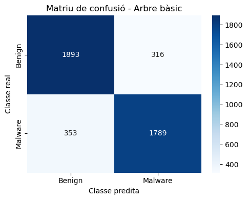

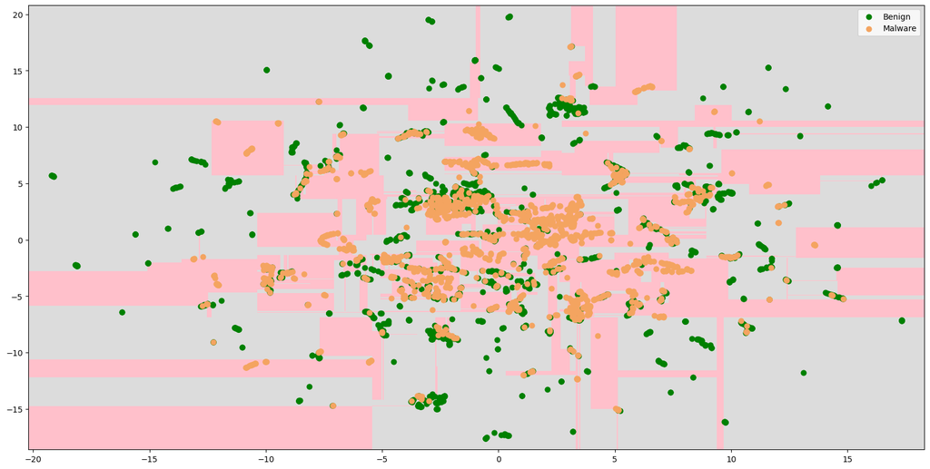

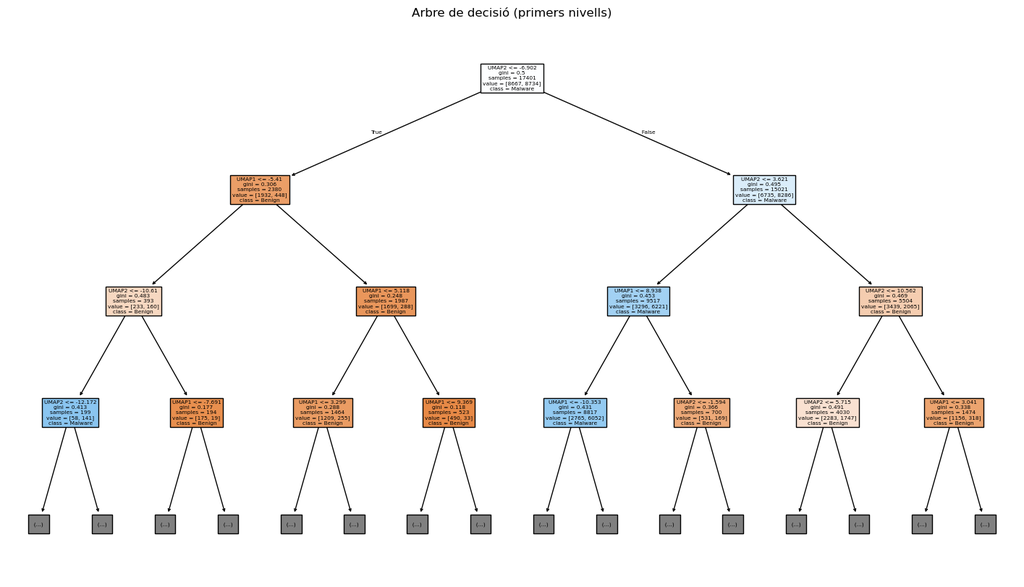

```python
from sklearn.tree import plot_tree

# 1) Arbre per defecte (només fixem random_state per reproduïbilitat)
tree_basic = DecisionTreeClassifier(random_state=24)
tree_basic.fit(X_train_projection, y_train)

# 2) Prediccions
y_train_pred_tree_basic = tree_basic.predict(X_train_projection)
y_test_pred_tree_basic = tree_basic.predict(X_test_projection)

# 3) Accuracy
acc_train_tree_basic = accuracy_score(y_train, y_train_pred_tree_basic)
acc_test_tree_basic = accuracy_score(y_test, y_test_pred_tree_basic)

print(f"Accuracy arbre bàsic - train: {acc_train_tree_basic:.4f}")
print(f"Accuracy arbre bàsic - test : {acc_test_tree_basic:.4f}")

# 4) Matriu de confusió
cm_tree_basic = confusion_matrix(y_test, y_test_pred_tree_basic)

plt.figure(figsize=(5, 4))
sns.heatmap(cm_tree_basic,
            annot=True, fmt='d',
            cmap='Blues',
            xticklabels=labels,
            yticklabels=labels)
plt.xlabel('Classe predita')
plt.ylabel('Classe real')
plt.title('Matriu de confusió - Arbre bàsic')
plt.tight_layout()
plt.show()

# 5) Frontera de decisió
plot_decision_boundaries(tree_basic, X_test_projection, y_test)

# 6) Representació de l'arbre (trunquem la profunditat per llegir-lo millor)
plt.figure(figsize=(18, 10))
plot_tree(
    tree_basic,
    feature_names=['UMAP1', 'UMAP2'],
    class_names=labels,
    filled=True,
    max_depth=3   # només mostrem els 3 primers nivells per visualitzar
)
plt.title("Arbre de decisió (primers nivells)")
plt.show()
```

**Anàlisi:**

1. Avalua i comenta els resultats obtinguts amb l'arbre de decisió. Considera tant l'*accuracy* del model en els conjunts de *train* i *test* com els resultats de la matriu de confusió.
2. Reflexiona sobre com la frontera de decisió visualitzada en el conjunt de *test* s'alinea amb els resultats obtinguts. És coherent amb el que esperaries d'un arbre de decisió?
3. Observa la representació gràfica de l'arbre. Analitza com les diferents ramificacions i decisions preses en l'arbre expliquen el comportament del model i el seu impacte en la classificació de les dades.

Aquesta anàlisi t'ajudarà a comprendre en profunditat el funcionament i l'eficàcia de l'arbre de decisió en el teu conjunt de dades específic.

1.En train l’arbre bàsic té accuracy = 1.000 → s’ajusta perfectament a les dades d’entrenament, senyal clar de sobreajustament per la profunditat per defecte.

En test baixa a ~0.85, que és un bon rendiment però clarament pitjor que en train. La matriu de confusió mostra uns 316 falsos positius (benignes classificats com a malware) i 353 falsos negatius (malware classificat com a benigne), força equilibrats. El model funciona raonablement bé, però paga el preu de la seva complexitat amb una certa pèrdua de generalització.

2.Frontera de decisió en UMAP: A la projecció 2D, la frontera és un mosaic de franges i rectangles horitzontals/verticals, exactament el que esperem d’un arbre de decisió, que fa particions axis-aligned sobre cada atribut.

Les zones uniformes de color (regions predites com una mateixa classe) coincideixen amb concentracions de punts de la classe corresponent, i els errors es troben sobretot a les bandes on les dues classes es barregen, de manera que la frontera és coherent amb els resultats de la matriu de confusió.

3.Interpretació de l’arbre: En la representació gràfica, cada node interior fa una comparació sobre UMAP1 o UMAP2 amb un llindar; això segmenta l’espai pas a pas en subregions cada vegada més específiques.

Les fulles indiquen la classe majoritària i el nombre de mostres de cada classe; veiem que, a mesura que baixem pel camí d’un node, quedem en regions on predomina clarament una de les dues classes, i això explica la bona accuracy en train.

En resum, l’arbre és molt expressiu (moltes ramificacions) i això li permet adaptar-se bé a l’estructura de les dades, però també el fa més sensible al soroll i explica la diferència tan gran entre el rendiment en train i en test.

#### Evitant l'*overfitting*

El procés de construcció d'arbres descrit tendeix a reduir ràpidament l'error d'entrenament, per la qual cosa generalment el model s'ajusta molt bé a les observacions utilitzades com a entrenament (conjunt de *train*). Com a conseqüència, els arbres de decisió tendeixen a l'*overfitting*.

Per evitar l'*overfitting* en els arbres de decisió, és crucial que modifiquis certs hiperparàmetres del model de la manera següent:

1. Utilitza l'hiperparàmetre `max_depth`, que defineix la profunditat màxima de l'arbre. Hauràs d'explorar els valors entre 4 i 10 per trobar l'equilibri adequat entre la complexitat del model i la seva capacitat per generalitzar.
2. Estableix l'hiperparàmetre `min_samples_split`, que és el nombre mínim d'observacions que ha de tenir una fulla de l'arbre abans de considerar una divisió. Experimenta amb valors com 2, 10, 20, 50 i 100 per assegurar-te que l'arbre no es torni massa específic per a les observacions d'entrenament.

Ajustant aquests hiperparàmetres, podràs controlar la tendència de l'arbre de decisió a sobreajustar-se al conjunt d'entrenament, millorant així la seva capacitat per realitzar prediccions efectives en noves dades."

**Implementació:**

1. Calcula el valor òptim dels hiperparàmetres `max_depth` i `min_samples_split` utilitzant una cerca de reixeta amb validació creuada. Aquest procés t'ajudarà a trobar els valors òptims que evitaran el sobreajustament.
2. Per a cada combinació de valors, calcula la seva mitjana i la desviació estàndard.
3. Fes un *heatmap* per visualitzar la precisió segons els diferents valors dels hiperparàmetres.

Utilitza el mòdul `GridSearchCV` de `sklearn` per calcular els millors hiperparàmetres amb el classificador `DecisionTreeClassifier` de `tree` de `sklearn`. Per a la visualització del *heatmap*, empra la llibreria `Seaborn`.

Aquests passos et permetran identificar de manera efectiva i visual els valors de `max_depth` i `min_samples_split` que maximitzen la precisió del teu arbre de decisió, minimitzant el risc de sobreajustament.

```
Millors hiperparàmetres arbre: {'max_depth': 10, 'min_samples_split': 20}
Millor accuracy de cross-validation: 0.8347
```

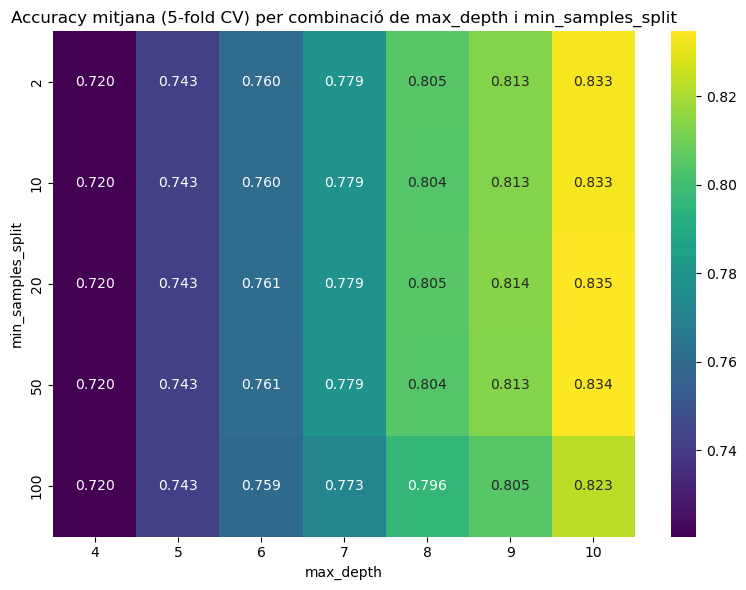

```python
# 0) Definim l'esquema de validació creuada estratificada (5 particions)
#    Ho fem per mantenir la proporció de classes a cada "fold".
cv = StratifiedKFold(n_splits=5, shuffle=True, random_state=24)

# 1) Definim l'arbre base de classificació
#    Només fixem random_state per poder reproduir els resultats.
tree_clf = DecisionTreeClassifier(random_state=24)

# 2) Definim la graella d'hiperparàmetres que volem explorar
#    max_depth: profunditat màxima de l'arbre
#    min_samples_split: mínim d'exemples per fer una divisió interna
param_grid_tree = {
    "max_depth": list(range(4, 11)),          # 4,5,6,7,8,9,10
    "min_samples_split": [2, 10, 20, 50, 100]
}

# 3) Configurem el GridSearchCV
#    - estimator: l'arbre de decisió
#    - param_grid: la graella de paràmetres
#    - scoring: accuracy, perquè és el que volem maximitzar
#    - cv: validació creuada estratificada
#    - n_jobs: -1 per utilitzar tots els nuclis disponibles
#    - return_train_score: per poder analitzar també l'accuracy en train
grid_tree = GridSearchCV(
    estimator=tree_clf,
    param_grid=param_grid_tree,
    scoring="accuracy",
    cv=cv,
    n_jobs=-1,
    return_train_score=True
)

# 4) Ajustem el grid sobre les dades de TRAIN projectades amb UMAP
#    (X_train_projection té forma (n_mostres, 2))
grid_tree.fit(X_train_projection, y_train)

print("Millors hiperparàmetres arbre:", grid_tree.best_params_)
print(f"Millor accuracy de cross-validation: {grid_tree.best_score_:.4f}")

# 5) Convertim els resultats de la CV en un DataFrame per analitzar-los
results_tree = pd.DataFrame(grid_tree.cv_results_)

# Els paràmetres vénen com a objectes; els passem a int per poder fer la taula pivot
results_tree["param_max_depth"] = results_tree["param_max_depth"].astype(int)
results_tree["param_min_samples_split"] = results_tree["param_min_samples_split"].astype(int)

# 6) Creem una taula pivot:
#    - files: min_samples_split
#    - columnes: max_depth
#    - valors: mean_test_score (accuracy mitjana en CV)
pivot_tree = results_tree.pivot(
    index="param_min_samples_split",
    columns="param_max_depth",
    values="mean_test_score"
)

# 7) Heatmap per visualitzar la precisió segons cada combinació d'hiperparàmetres
plt.figure(figsize=(8, 6))
sns.heatmap(
    pivot_tree,
    annot=True, fmt=".3f",
    cmap="viridis"
)
plt.xlabel("max_depth")
plt.ylabel("min_samples_split")
plt.title("Accuracy mitjana (5-fold CV) per combinació de max_depth i min_samples_split")
plt.tight_layout()
plt.show()
```

**Implementació:**

1. Entrena un arbre de decisió amb el dataset d'entrenament (*train*) utilitzant la millor combinació de paràmetres que hagis trobat.
2. Calcula l'*accuracy* (precisió) del model tant en les dades de *train* com de *test*.
3. Calcula la matriu de confusió utilitzant les dades de *test*.
4. Representa gràficament la frontera de decisió amb les dades de *test*.
5. Representa l'arbre de decisió.

Aquests passos et permetran avaluar com l'arbre de decisió, ajustat amb els hiperparàmetres òptims, es comporta en el teu conjunt de dades, tant en termes de classificació com en la seva representació visual."

```
Millor max_depth: 10
Millor min_samples_split: 20
Accuracy arbre òptim - train: 0.8468
Accuracy arbre òptim - test : 0.8265
```

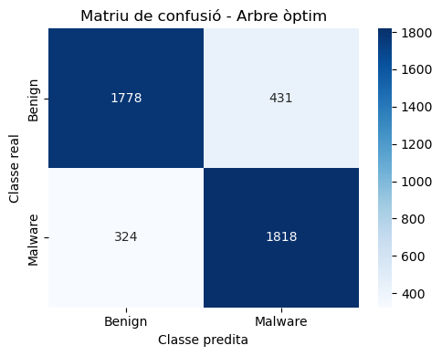

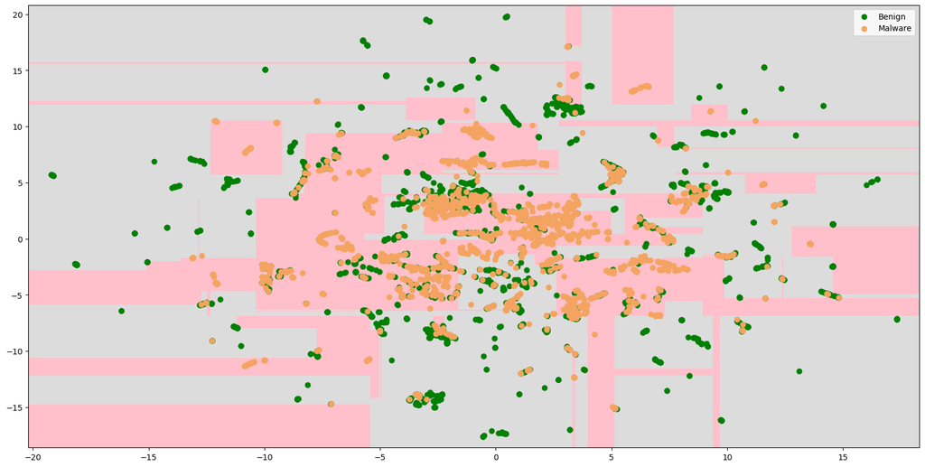

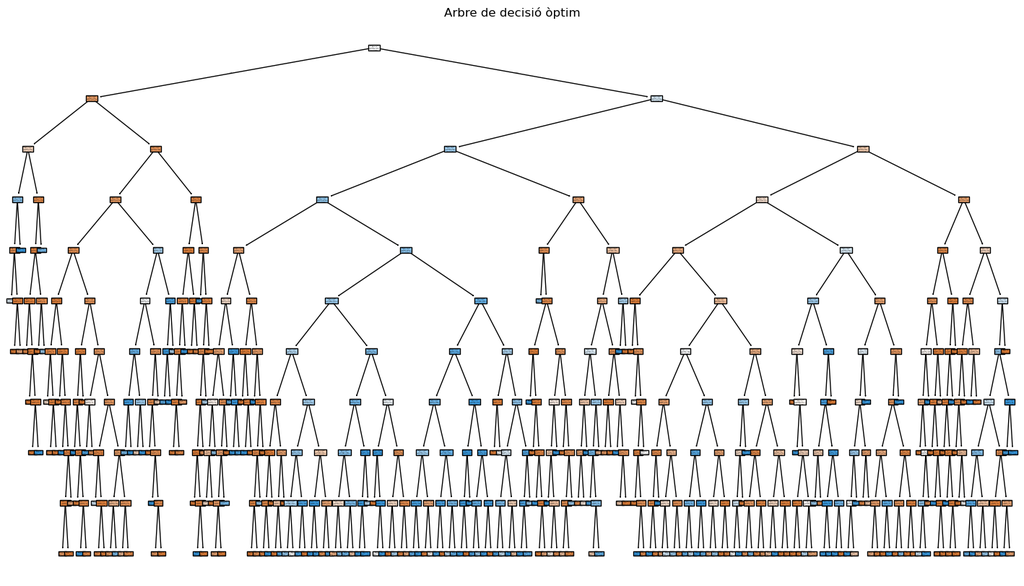

```python
best_depth = grid_tree.best_params_['max_depth']
best_min_samples_split = grid_tree.best_params_['min_samples_split']

print("Millor max_depth:", best_depth)
print("Millor min_samples_split:", best_min_samples_split)

# 1) Entrenem l'arbre òptim
tree_best = DecisionTreeClassifier(
    random_state=24,
    max_depth=best_depth,
    min_samples_split=best_min_samples_split
)
tree_best.fit(X_train_projection, y_train)

# 2) Prediccions
y_train_pred_tree_best = tree_best.predict(X_train_projection)
y_test_pred_tree_best = tree_best.predict(X_test_projection)

# 3) Accuracy
acc_train_tree_best = accuracy_score(y_train, y_train_pred_tree_best)
acc_test_tree_best = accuracy_score(y_test, y_test_pred_tree_best)

print(f"Accuracy arbre òptim - train: {acc_train_tree_best:.4f}")
print(f"Accuracy arbre òptim - test : {acc_test_tree_best:.4f}")

# 4) Matriu de confusió
cm_tree_best = confusion_matrix(y_test, y_test_pred_tree_best)

plt.figure(figsize=(5, 4))
sns.heatmap(cm_tree_best,
            annot=True, fmt='d',
            cmap='Blues',
            xticklabels=labels,
            yticklabels=labels)
plt.xlabel('Classe predita')
plt.ylabel('Classe real')
plt.title('Matriu de confusió - Arbre òptim')
plt.tight_layout()
plt.show()

# 5) Frontera de decisió
plot_decision_boundaries(tree_best, X_test_projection, y_test)

# 6) Arbre de decisió (ara amb els hiperparàmetres òptims)
plt.figure(figsize=(18, 10))
plot_tree(
    tree_best,
    feature_names=['UMAP1', 'UMAP2'],
    class_names=labels,
    filled=True,
    max_depth=best_depth  # pots limitar-lo si és massa gran per llegir
)
plt.title("Arbre de decisió òptim")
plt.show()
```

**Anàlisi:**

1. Avalua i comenta els resultats obtinguts en la cerca dels millors hiperparàmetres. Considera com la combinació òptima de `max_depth` i `min_samples_split` ha impactat el rendiment de l'arbre de decisió.
2. Examina les fronteres de decisió generades amb el conjunt de *test*. Reflexiona sobre si la forma d'aquestes fronteres és coherent amb el que esperaries d'un arbre de decisió configurat amb aquests hiperparàmetres.
3. Analitza les prediccions realitzades sobre el conjunt de test. Observa la seva precisió i com es distribueixen en relació amb les fronteres de decisió. Són consistents aquestes prediccions amb l'estructura de l'arbre de decisió i les fronteres observades?

Aquesta anàlisi t'ajudarà a comprendre l'eficàcia de l'arbre de decisió amb els hiperparàmetres seleccionats i el seu impacte en la classificació de les dades.

1. Hiperparàmetres (max_depth, min_samples_split)

A la graella es veu que, quan max_depth creix de 4 a 10, l’accuracy de CV puja d’uns ~0.72 fins a ~0.83.

El millor rendiment s’assoleix a max_depth = 10 i min_samples_split = 20: permet un arbre prou profund per capturar patrons, però obliga a tenir prou mostres per dividir i així limita l’overfitting.

Això es veu en les accuracies: el train baixa a ~0.85 (ja no “memoriza” el train com abans) i el test es queda al voltant de 0.83, coherent amb la CV.

2. Fronteres de decisió

Les fronteres són blocs rectangulars, alineats als eixos, típic d’un arbre de decisió.

Amb max_depth=10 hi ha força detall (moltes “caixes”), però menys fragmentació extrema que en un arbre sense restriccions.

La forma és coherent amb els hiperparàmetres: prou profunditat per adaptar-se a la complexitat de les dades, però min_samples_split=20 evita particions molt petites i sorolloses.

3. Prediccions sobre el test

La matriu de confusió mostra una accuracy ~0.83 amb errors raonablement repartits (324 malwares classificats com benignes i 431 benignes com malwares).

Al gràfic, la majoria de punts “Malware” queden dins zones roses i la majoria de “Benign” en zones grises; els errors apareixen just en àrees on les classes es barregen, com és d’esperar.

En conjunt, les prediccions són consistents amb les fronteres: model bastant ajustat, però encara amb certa confusió en zones on el patró no és clar.

# 2. Comprensió d'algorismes supervisats (2.5 punts)

En aquest exercici aprofundirem en la comprensió dels algorismes supervisats que hem estudiat, en concret, Arbres de decisió i Knn. Per a això treballarem amb un problema de regressió molt senzill (un únic atribut descriptiu) que es resoldria de forma directa amb una regressió lineal.

**IMPORTANT:** En aquest exercici no es poden utilitzar altres models, ni tècniques com *ensemble learning* ni usar altres llibreries diferents de les indicades i importades a l'inici de la PAC. En aquest exercici hem de seguir les indicacions que es proporcionaran en cada secció, on ens centrarem a transformar el problema (dades) per aconseguir resoldre el nostre problema.

En aquest exercici ens recolzarem en la funció *plot_regression*, la qual ens permetrà representar de forma senzilla les solucions obtingudes.

**NOTA:** En aquest exercici realitzarem moltes anàlisis visuals amb l'objectiu d'aprofundir en els coneixements teòrics vistos al mòdul. Aquest exercici es realitzarà amb una finalitat didàctica; en la realitat sempre cal basar-se en diverses mètriques objectives per al problema que estiguem resolent, a més, per descomptat, de visualitzar si és possible el problema que estiguem resolent.

```python
def plot_regression(x_train, y_train, x_test, y_test, preds_train=None, preds_test=None):
    plt.figure(figsize=(15, 8))
    plt.scatter(x_train, y_train, s=60, marker='8', label='train')
    plt.scatter(x_test, y_test, s=60, marker='8', label='test')

    if preds_train is not None:
        plt.scatter(x_train, preds_train, s=60, marker='8', label='preds_train')

    if preds_test is not None:
        plt.scatter(x_test, preds_test, s=60, marker='8', label='preds_test')

    plt.legend()
    plt.show()
```

En la següent cel·la es defineix el conjunt de dades i se separa en entrenament i test, com es pot observar en la gràfica

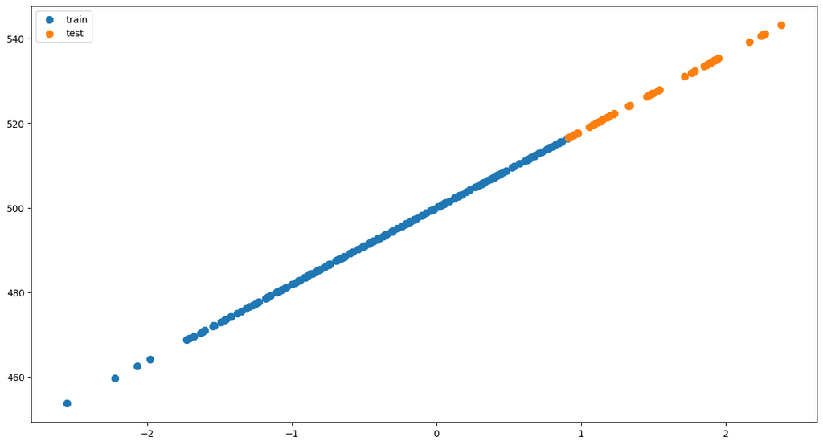

```python
n_samples = 250
test_size = int(n_samples * 0.2)
X, y = datasets.make_regression(n_features=1, n_samples=n_samples, bias=500, noise=0, random_state=0)
X, y = zip(*sorted(zip(X,y)))
X = np.array(X); y = np.array(y)

X_train = X[:-test_size]
X_test = X[-test_size:]

y_train = y[:-test_size]
y_test = y[-test_size:]

plot_regression(X_train, y_train, X_test, y_test)
```

**Implementació:**

1. Calcula el valor òptim dels hiperparàmetres `max_depth` i `min_samples_split` per a un arbre de decisió utilitzant una cerca de reixeta amb validació creuada i la mètrica 'r2_score'. Aquest procés t'ajudarà a trobar els valors òptims que evitaran el sobreajustament.
2. Per a cada combinació de valors, calcula la seva mitjana i la desviació estàndard.
3. Mostra el valor òptim trobat per als dos hiperparàmetres.
4. Entrena un arbre de decisió amb el dataset d'entrenament (*train*) utilitzant la millor combinació de paràmetres que hagis trobat.
5. Realitza la predicció sobre el conjunt d'entrenament (*train*) i test per representar gràficament els resultats utilitzant la funció `plot_regression`. Tingues en compte que necessitem visualitzar les 4 sèries: *train*, *test*, predicció sobre *train* i predicció sobre *test*.

Utilitza el mòdul `GridSearchCV` de `sklearn` per calcular els millors hiperparàmetres amb el classificador `DecisionTreeRegressor` de `tree` de `sklearn`.

```
Top 10 combinacions (ordenades per R2 mitjà de validació):
    param_max_depth  param_min_samples_split  mean_test_score  std_test_score
25                9                        2        -0.766195        0.915933
30               10                        2        -0.766195        0.915933
20                8                        2        -0.768150        0.915514
15                7                        2        -0.773735        0.913520
10                6                        2        -0.849738        0.929240
5                 5                        2        -1.060474        0.899816
26                9                       10        -1.306969        0.822399
21                8                       10        -1.306969        0.822399
11                6                       10        -1.306969        0.822399
16                7                       10        -1.306969        0.822399

Millors hiperparàmetres trobats:
{'max_depth': 9, 'min_samples_split': 2}

R2 arbre òptim - train: 1.0000
R2 arbre òptim - test : -1.6975
```

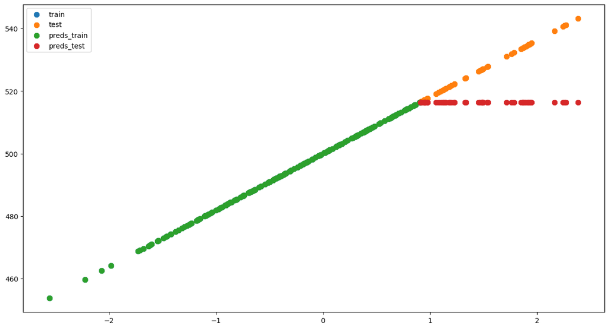

```python
from sklearn.metrics import r2_score

# 1) Definim el model base d'arbre de decisió per a regressió
reg_tree = DecisionTreeRegressor(random_state=24)

# 2) Definim la graella d'hiperparàmetres a explorar
param_grid = {
    "max_depth": list(range(4, 11)),          # 4, 5, ..., 10
    "min_samples_split": [2, 10, 20, 50, 100]
}

# 3) GridSearchCV amb mètrica R2 (equivalent a r2_score) i validació creuada 5-fold
grid_reg_tree = GridSearchCV(
    estimator=reg_tree,
    param_grid=param_grid,
    scoring="r2",          # fa servir r2_score internament
    cv=5,
    n_jobs=-1,
    return_train_score=True
)

# Ajustem el grid sobre el conjunt d'entrenament
# (X_train ha de ser 2D: (n_mostres, n_features))
grid_reg_tree.fit(X_train.reshape(-1, 1), y_train)

# 4) Resumim els resultats: mitjana i desviació estàndard per a cada combinació
results = pd.DataFrame(grid_reg_tree.cv_results_)

results_summary = results[
    ["param_max_depth", "param_min_samples_split", "mean_test_score", "std_test_score"]
].sort_values("mean_test_score", ascending=False)

print("Top 10 combinacions (ordenades per R2 mitjà de validació):")
print(results_summary.head(10))

# 5) Mostrem el millor conjunt d'hiperparàmetres
print("\nMillors hiperparàmetres trobats:")
print(grid_reg_tree.best_params_)

# 6) Entrenem un arbre amb la millor combinació de paràmetres
best_tree = grid_reg_tree.best_estimator_

# Prediccions sobre train i test
y_train_pred = best_tree.predict(X_train.reshape(-1, 1))
y_test_pred  = best_tree.predict(X_test.reshape(-1, 1))

# R2 en train i test com a informació extra
r2_train = best_tree.score(X_train.reshape(-1, 1), y_train)  # r2_score intern
r2_test  = best_tree.score(X_test.reshape(-1, 1), y_test)

print(f"\nR2 arbre òptim - train: {r2_train:.4f}")
print(f"R2 arbre òptim - test : {r2_test:.4f}")

# 7) Representem gràficament les 4 sèries amb plot_regression
plot_regression(
    X_train, y_train,
    X_test, y_test,
    preds_train=y_train_pred,
    preds_test=y_test_pred
)
```

**Anàlisi:**

1. Analitza visualment les prediccions sobre el conjunt d'entrenament, s'adapta bé el model a aquest conjunt de dades? hi ha *overfitting*? per què?
2. Analitza visualment les prediccions sobre el conjunt de *test*, s'adapta bé el model a aquest conjunt de dades? per què?
3. És l'arbre de decisió un bon model per al problema que estem resolent? per què?

En aquesta anàlisi s'ha de reflexionar sobre els resultats, justificant el comportament del model basant-se en els conceptes teòrics apresos en aquest mòdul.

1.Prediccions sobre el conjunt d’entrenament: En el gràfic veiem que els punts de preds_train (verd) se superposen pràcticament als punts de train (blau): la línia verda és, visualment, la mateixa recta que descriuen les dades reals. Això es reflecteix en el valor de R^2_train = 1.000.

Això indica que l’arbre s’ajusta perfectament al conjunt d’entrenament. Des del punt de vista teòric, un arbre de regressió amb profunditat alta i min_samples_split petit pot crear moltes particions, de manera que cada fulla conté molt poques mostres i pot “memoritzar” els valors de training. Aquest és un cas típic de sobreajustament (overfitting): variància molt alta i biaix gairebé nul sobre el train.

2.Prediccions sobre el conjunt de test: En el segon gràfic, les prediccions sobre test (preds_test, vermell) formen gairebé una franja horitzontal al voltant d’un valor proper als 515, mentre que les dades de test reals (taronja) continuen la mateixa recta creixent que ja vèiem en train.

Això ens diu que:

- L’arbre, un cop surt de la zona exacta on ha vist dades de train, tendeix a donar valors constants (la mitjana de la fulla on cau).
- No és capaç d’extrapolar la tendència lineal; només “repeteix” el que ha après a les regions on tenia mostres.

El resultat numèric ho confirma:R^2_test ≪0 (−1.69), cosa que indica que el model ho fa pitjor que una recta horitzontal que predigués sempre la mitjana. Això és la conseqüència directa de l’overfitting: el model és massa complex, ajusta molt bé el train però generalitza molt malament.

3.És l’arbre de decisió un bon model per a aquest problema?: Per aquest problema concret, la resposta és no, no és el model més adequat:

- La relació entre 𝑋 i 𝑦 és clarament lineal i suau (una recta).
- Un arbre de regressió aproxima la funció mitjançant valors constants per intervals (funció esglaonada). Per reproduir bé una recta llarga, hauria de fer molts talls petits → arbre molt profund → molta variància i overfitting.
- Models paramètrics simples com una regressió lineal capturen molt millor aquest tipus de dependència global amb pocs paràmetres i generalitzen molt millor.

Per tant, el que veiem és el que la teoria del mòdul anticipa: els arbres de decisió són molt flexibles i poden ajustar problemes complexos i no lineals, però en una regressió purament lineal, aquesta flexibilitat es converteix en un inconvenient, perquè el model tendeix a sobreajustar i no generalitza bé fora del conjunt d’entrenament.

**Implementació:** En aquesta secció transformarem el problema per ajudar l'arbre de decisió a realitzar millors prediccions. Per a això:

1. Crea un nou conjunt de dades *transformed_X_train* i *transformed_X_test* a partir dels conjunts originals *X_train* i *X_test* de manera que cada valor del conjunt transformat sigui la diferència del seu corresponent valor original (en base a la seva posició en el conjunt de dades) menys el valor previ del conjunt original. És a dir: transformed[i] = original[i] - original[i-1]. Presta especial atenció al primer valor del conjunt de dades.
2. Crea un nou conjunt de dades *transformed_y_train* i *transformed_y_test* a partir dels conjunts originals *y_train* i *y_test* aplicant la mateixa lògica del punt anterior.
3. Representa gràficament el nou problema utilitzant la funció `plot_regression`

Amb aquesta transformació, predirem l'increment de la regressió en lloc del valor absolut.

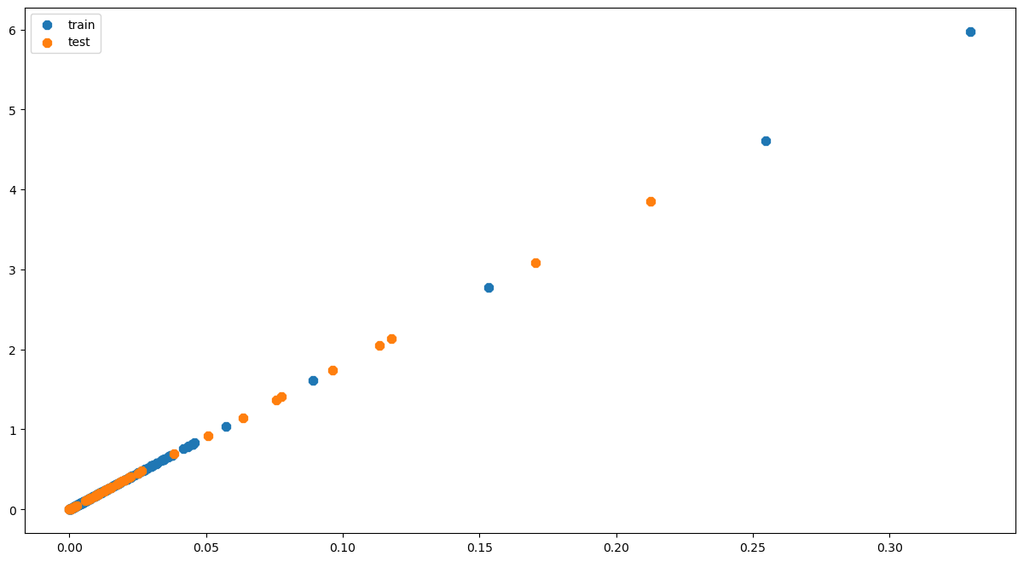

```python
def first_order_diff(arr):
    """
    Donat un vector 1D, retorna el vector d'increments:
      diff[i] = arr[i] - arr[i-1]
    definint diff[0] = 0 perquè no tenim valor anterior.
    """
    arr = np.asarray(arr).ravel()
    diffs = np.empty_like(arr, dtype=float)
    diffs[0] = 0.0
    diffs[1:] = arr[1:] - arr[:-1]
    return diffs

# 1) Creem transformed_X_train i transformed_X_test
transformed_X_train = first_order_diff(X_train)
transformed_X_test  = first_order_diff(X_test)

# 2) Creem transformed_y_train i transformed_y_test
transformed_y_train = first_order_diff(y_train)
transformed_y_test  = first_order_diff(y_test)

# 3) Representem gràficament el nou problema amb plot_regression
plot_regression(
    transformed_X_train, transformed_y_train,
    transformed_X_test, transformed_y_test
)
```

**Anàlisi:** Analitza visualment el nou problema que resoldrem i justifica basant-te en els conceptes teòrics apresos en aquest mòdul, el motiu pel qual l'arbre de decisió s'hauria d'adaptar millor a aquest problema.

Visualment veiem que, després de la transformació, el nou problema (increments) deixa de ser una recta “llarga” en l’eix vertical i es converteix en una relació molt més compacta i local:

Tant transformed_X com transformed_y queden concentrats en valors petits i positius, amb una tendència creixent però suau.

La majoria de punts s’agrupen a prop de l’origen i només a les vores hi ha increments més grans.

Des del punt de vista teòric, un arbre de regressió aproxima la funció amb valors constants per intervals (funció esglaonada). En el problema original, l’arbre havia de “seguir” una recta molt llarga -> necessitava molts talls i fulles molt petites -> alta variància i sobreajustament. En canvi, en el problema d’increments:

Això encaixa molt millor amb la idea de “mitjana per regió” de les fulles: amb pocs splits podem agrupar increments similars i aproximar bé la relació.

Per tant, esperem que l’arbre, treballant sobre els increments, necessiti menys profunditat, tingui menys variància i generalitzi millor. Després, en reconstruir els valors originals mitjançant la suma acumulada, aquesta bona aproximació dels increments es traduirà en una millor aproximació de la recta original.

**Implementació:** Repetirem el procés d'entrenament i predicció sobre el **nou conjunt de dades transformat**. Per a això:

1. Calcula el valor òptim dels hiperparàmetres `max_depth` i `min_samples_split` per a un arbre de decisió utilitzant una cerca de reixeta amb validació creuada i la mètrica 'r2_score'. Aquest procés t'ajudarà a trobar els valors òptims que evitaran el sobreajustament.
2. Per a cada combinació de valors, calcula la seva mitjana i la desviació estàndard.
3. Mostra el valor òptim trobat per als dos hiperparàmetres.
4. Entrena un arbre de decisió amb el dataset d'entrenament (*train*) utilitzant la millor combinació de paràmetres que hagis trobat.
5. Realitza la predicció sobre el conjunt d'entrenament (*train*) i test per representar gràficament els resultats utilitzant la funció `plot_regression`. Tingues en compte que necessitem visualitzar les 4 sèries: *train*, *test*, predicció sobre *train* i predicció sobre *test*.

Utilitza el mòdul `GridSearchCV` de `sklearn` per calcular els millors hiperparàmetres amb el classificador `DecisionTreeClassifier` de `tree` de `sklearn`.

```
Top 10 combinacions (problema transformat, ordenades per R2 mitjà):
    param_max_depth  param_min_samples_split  mean_test_score  std_test_score
30               10                        2         0.832569        0.333625
25                9                        2         0.832565        0.333623
20                8                        2         0.832523        0.333602
15                7                        2         0.832251        0.333466
10                6                        2         0.831367        0.333027
5                 5                        2         0.825801        0.330257
26                9                       10         0.821085        0.331342
31               10                       10         0.821085        0.331342
21                8                       10         0.821085        0.331342
16                7                       10         0.821080        0.331339

Millors hiperparàmetres trobats (problema transformat):
{'max_depth': 10, 'min_samples_split': 2}
Millor R2 de cross-validation (transformat): 0.8326

R2 arbre òptim (transformat) - train: 1.0000
R2 arbre òptim (transformat) - test : 0.9586
```

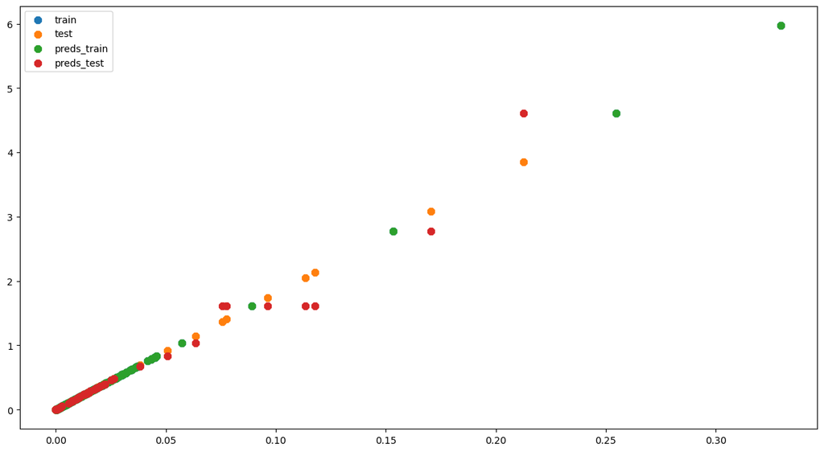

```python
# 1) Model base d'arbre de decisió per al PROBLEMA TRANSFORMAT
reg_tree_trans = DecisionTreeRegressor(random_state=24)

# 2) Graella d'hiperparàmetres a explorar
param_grid_trans = {
    "max_depth": list(range(4, 11)),          # 4, 5, ..., 10
    "min_samples_split": [2, 10, 20, 50, 100]
}

# 3) GridSearchCV amb mètrica R2 i validació creuada 5-fold
grid_reg_tree_trans = GridSearchCV(
    estimator=reg_tree_trans,
    param_grid=param_grid_trans,
    scoring="r2",          # utilitza r2_score internament
    cv=5,
    n_jobs=-1,
    return_train_score=True
)

# Ajustem el grid sobre el conjunt d'entrenament TRANSFORMAT
grid_reg_tree_trans.fit(transformed_X_train.reshape(-1, 1), transformed_y_train)

# 4) Resumim els resultats: mitjana i desviació estàndard per a cada combinació
results_trans = pd.DataFrame(grid_reg_tree_trans.cv_results_)

results_trans_summary = results_trans[
    ["param_max_depth", "param_min_samples_split", "mean_test_score", "std_test_score"]
].sort_values("mean_test_score", ascending=False)

print("Top 10 combinacions (problema transformat, ordenades per R2 mitjà):")
print(results_trans_summary.head(10))

# 5) Mostrem el millor conjunt d'hiperparàmetres
best_params_trans = grid_reg_tree_trans.best_params_
print("\nMillors hiperparàmetres trobats (problema transformat):")
print(best_params_trans)
print(f"Millor R2 de cross-validation (transformat): {grid_reg_tree_trans.best_score_:.4f}")

# 6) Entrenem un arbre amb la millor combinació de paràmetres
best_tree_trans = grid_reg_tree_trans.best_estimator_

# 7) Prediccions sobre train i test (espai transformat)
y_train_pred_diff = best_tree_trans.predict(transformed_X_train.reshape(-1, 1))
y_test_pred_diff  = best_tree_trans.predict(transformed_X_test.reshape(-1, 1))

# 8) R2 en train i test en el PROBLEMA TRANSFORMAT
r2_train_trans = r2_score(transformed_y_train, y_train_pred_diff)
r2_test_trans  = r2_score(transformed_y_test,  y_test_pred_diff)

print(f"\nR2 arbre òptim (transformat) - train: {r2_train_trans:.4f}")
print(f"R2 arbre òptim (transformat) - test : {r2_test_trans:.4f}")

# 9) Representem gràficament les 4 sèries amb plot_regression
plot_regression(
    transformed_X_train, transformed_y_train,
    transformed_X_test, transformed_y_test,
    preds_train=y_train_pred_diff,
    preds_test=y_test_pred_diff
)
```

**Anàlisi:** Analitza visualment les prediccions en el nou problema, s'adapta millor l'arbre de decisió al problema?

Sí, en el problema transformat veiem clarament que l’arbre de decisió s’hi adapta molt millor:

Numèricament, el R^2 passa de ser molt dolent (negatiu) en el problema original a 1.000 en train i 0.9586 en test en el problema d’increments. Això indica que el model explica gairebé tota la variabilitat també en dades noves.

Des del punt de vista teòric, això és el que esperàvem: en lloc d’intentar aproximar una recta molt llarga amb esglaons (on l’arbre sobreajustava i no sabia extrapolar), ara l’arbre només ha d’aprendre una funció d’increments petits i relativament homogenis, molt més adequada per a una aproximació per “mitjanes per intervals”. El resultat és un arbre amb bona capacitat de generalització i sense el problema d’overfitting extrem que teníem abans.

**Implementació:** En aquesta secció desfarem la transformació aplicada per comprovar si el nou model resol el problema original. Per a això:

1. Crea un nou conjunt de dades *original_preds_train* i *original_preds_test* a partir dels conjunts originals *preds_train* i *preds_test* desfent la transformació que hem aplicat al problema. És a dir: original[i] = original[i-1] + transformed[i]. Presta especial atenció al primer valor del conjunt de dades.
2. Representa gràficament els resultats utilitzant la funció `plot_regression`. Tingues en compte que necessitem visualitzar les 4 sèries: *train*, *test*, predicció sobre *train* i predicció sobre *test*.

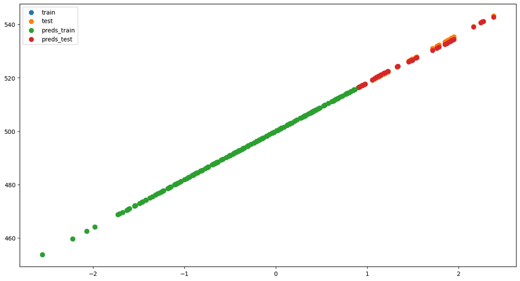

```python
def undo_first_order_diff(diffs, first_value):
    """
    Reconstrueix els valors originals a partir d'un vector d'increments (diffs)
    i el primer valor original conegut (first_value).

    Fem:
        original[0] = first_value
        original[i] = original[i-1] + diffs[i]
    """
    diffs = np.asarray(diffs).ravel()
    original = np.empty_like(diffs, dtype=float)
    original[0] = first_value
    for i in range(1, len(diffs)):
        original[i] = original[i-1] + diffs[i]
    return original

# 1) Reconstruïm original_preds_train i original_preds_test
#    y_train_pred_diff i y_test_pred_diff són les prediccions sobre el problema transformat
preds_train = y_train_pred_diff
preds_test  = y_test_pred_diff

original_preds_train = undo_first_order_diff(preds_train, y_train[0])
original_preds_test  = undo_first_order_diff(preds_test,  y_test[0])

# 2) Representem els resultats en el problema ORIGINAL
#    Visualtizem les 4 sèries: train, test, preds_train i preds_test
plot_regression(
    X_train, y_train,
    X_test, y_test,
    preds_train=original_preds_train,
    preds_test=original_preds_test
)
```

**Anàlisi:** Analitza visualment les prediccions transformades al problema original, l'arbre de decisió aconsegueix resoldre el problema original? per què? Justifica la resposta basant-te en els conceptes teòrics apresos en aquest mòdul.

Sí, després de desfer la transformació podem dir que l’arbre de decisió resol molt bé el problema original.

Al gràfic final, els punts de preds_train (verd) i preds_test (vermell) queden pràcticament encavalcats sobre les sèries reals de train (blau) i test (taronja). Visualment gairebé tot són quatre punts superposats sobre la mateixa recta: la funció que hem reconstruït és, de facto, la mateixa que la regressió original.

El motiu teòric és que hem fet que l’arbre aprengui una funció molt més fàcil:

Quan fem la suma acumulada (undo_first_order_diff), aquesta bona aproximació dels increments es tradueix en una corba molt propera a la recta original.

Per tant, tot i que un arbre directe sobre 𝑦 sobreajustava i generalitzava malament, després de la transformació i la reconstrucció l’arbre és capaç de reproduir amb molta precisió el comportament original de la regressió, cosa coherent amb la teoria de biaix–variància i amb la manera com els arbres aproximen funcions mitjançant particions locals.

# 3. Implementació del cas pràctic (3 punts)

El negoci del videojoc està en constant creixement, per la qual cosa la inversió necessària per desenvolupar grans produccions també ha crescut any rere any. Per aquest motiu, predir si el videojoc que es desenvoluparà serà un èxit de vendes és crucial per als estudis i editors. En aquest exercici ens centrarem en un dataset que analitza gran part dels videojocs llançats des del 1995 fins al 2024. De cada videojoc s'han obtingut 6 característiques o atributs descriptius:

- Developer: Estudi o equip responsable de dissenyar i crear el videojoc.
- Publisher: Empresa encarregada de finançar, distribuir i promocionar el videojoc.
- Genres: Categories que descriuen el tipus d'experiència de joc (com acció, rol o esports).
- Product Rating: Etiqueta que indica la classificació per edats i el tipus de contingut del videojoc assignada per un organisme regulador.
- User Ratings Count: Nombre total de valoracions que els jugadors han deixat sobre un videojoc.
- year: Any en què s'ha posat a la venda el videojoc.
- Best-seller: Variable objectiu, indica si el joc ha estat un èxit de vendes (1) o no (0).

L'objectiu d'aquesta secció és abordar l'anàlisi d'aquest conjunt de dades i entrenar Arbres de decisió per predir si un videojoc serà un èxit de vendes. Aquí tens alguns passos que podries seguir:

1. **Anàlisi Exploratòria de Dades (EDA)**: Comença explorant el conjunt de dades per comprendre la seva estructura i distribució. Analitza la proporció de cada classe. Observa la distribució de les diferents característiques i la seva relació amb la classe objectiu "Best-seller".
2. **Preprocessament de Dades**: Considera normalitzar les característiques perquè estiguin en la mateixa escala que les components principals.
3. **Modelització**: Utilitza un arbre de decisió com a eina de classificació. Atès que l'objectiu és predir si el joc serà un èxit, és vital centrar-se en mètriques com la precisió, la sensibilitat (*recall*), el valor F1 i l'àrea sota la corba ROC (AUC-ROC).
4. **Avaluació**: Realitza una avaluació i anàlisi rigorosa del rendiment del teu model.

Aquest enfocament integral et permetrà no només construir un model efectiu sinó també comprendre millor les característiques subjacents de cada valor de la variable objectiu en el conjunt de dades.

## 3.1. Càrrega de dades

El primer que has de fer és carregar el conjunt de dades i visualitzar informació rellevant d'aquest. Assegura't de verificar el següent:

1. Confirma la quantitat total de files i columnes en el DataFrame.
2. Revisa el nom de cada columna del DataFrame.
3. Verifica el nombre de valors no nuls en cada columna.
4. Identifica el tipus de dades de cada columna, que pot ser int, float, object, entre d'altres.
5. Comprova la quantitat de memòria utilitzada pel DataFrame.

Aquests passos et proporcionaran una comprensió inicial clara i detallada del conjunt de dades amb el qual estàs treballant.

```python
data = pd.read_csv('videogames.csv')
data.info()
```

[output not shown]

## 3.2. Anàlisi Exploratòria de Dades (EDA) (0.75 punts)

L'Anàlisi Exploratòria de Dades (EDA, per les seves sigles en anglès) en ciència de dades és un enfocament inicial per comprendre i resumir el contingut d'un conjunt de dades. Aquest procés implica diverses tècniques i passos:

1. **Inspecció de Dades**: Es comença per revisar les dades brutes per identificar la seva estructura, mida i tipus (com numèric, categòric). Això inclou detectar valors faltants o inusuals.
2. **Resum Estadístic**: Es calculen estadístiques descriptives com la mitjana, mediana, rang, variància i desviació estàndard per obtenir una idea general de les tendències i patrons en les dades.
3. **Visualització de Dades**: S'utilitzen gràfics i diagrames (com histogrames, gràfics de caixa, diagrames de dispersió) per visualitzar distribucions, relacions entre variables i possibles anomalies. Això ajuda a comprendre millor les dades i a identificar patrons o irregularitats.
4. **Anàlisi de Relacions i Correlacions**: S'exploren les relacions entre diferents variables per entendre com s'influencien entre si. Això pot implicar l'ús de matrius de correlació i gràfics de dispersió.
5. **Identificació de Patrons i Anomalies**: Es busquen patrons consistents o anomalies (com valors atípics) que puguin suggerir tendències o problemes en les dades.

L'EDA és una fase crítica en qualsevol projecte de ciència de dades, ja que proporciona una comprensió profunda i una base sòlida per a posteriors anàlisis i modelatge.

**Implementació:**

1. Calcula les freqüències de la variable objectiu (`Best-seller`) en el teu conjunt de dades.
2. Crea un gràfic de barres per visualitzar aquestes freqüències. Això t'ajudarà a entendre la proporció de Best-seller respecte dels jocs que no van aconseguir complir les expectatives.

A continuació, analitza la distribució de les variables numèriques:

1. Representa gràficament l'histograma de les variables, separant les observacions segons la classe a la qual pertanyen.
2. Organitza tots els histogrames en un format de 2 files i 1 columna. Això facilitarà la comparació visual de les distribucions per a cada classe en cada variable.

Per últim, analitza la distribució de les variables categòriques de forma análoga a les variables numèriques, organitzant tots els histogrames en un format seqüencial.

Aquests passos et permetran obtenir una visió més clara de l'estructura del teu conjunt de dades i com les diferents variables poden influir en la identificació de best-sellers.

**Anàlisi:**

1. Avalua la relació de les freqüències de la variable `Best-seller`. Reflexiona sobre com es distribueixen els valors de la classe objectiu. És la distribució significativament desigual? Què implica això per a l'anàlisi i la modelització de les dades?
2. Analitza la informació proporcionada pels histogrames de les variables descriptores. Observa si hi ha diferències notables en les distribucions d'aquestes variables entre les classes. Pregunta't: Hi ha variables que mostrin patrons diferents en funció de si el joc és un èxit de vendes?
3. Considera si hi ha altres formes de visualització que podrien ser útils per entendre millor les dades. Per exemple, serien útils els diagrames de caixa (boxplots) per visualitzar la distribució de les variables en ambdues classes? Podria un mapa de calor de la matriu de correlació entre variables ajudar-te a entendre les relacions entre elles?

Aquesta anàlisi t'ajudarà a obtenir una comprensió més profunda de la naturalesa de les teves dades i a identificar possibles característiques que podrien ser importants per identificar els futurs blockbusters.

## 3.3. Preprocessament de Dades (0.75 punts)

El preprocessament de dades en ciència de dades és un pas crucial que involucra la preparació i transformació de dades brutes en un format adequat per a la seva posterior anàlisi i modelatge. Aquest procés inclou diverses tasques essencials:

1. **Neteja de Dades**: S'eliminen o corregeixen dades errònies, incompletes, inexactes o irrellevants. Això pot incloure tractar amb valors faltants, corregir errors d'entrada i gestionar valors atípics (*outliers*).
2. **Normalització i Escalament**: Les dades es transformen perquè estiguin en una escala comuna, sense distorsionar diferències en els rangs de valors ni perdre informació. Per exemple, escalament min-max o estandardització.
3. **Codificació de Variables Categòriques**: Les variables categòriques (com gènere o país) es converteixen en formats numèrics perquè puguin ser processades per algorismes d'aprenentatge automàtic, utilitzant tècniques com codificació *one-hot* o codificació d'etiquetes.
4. **Divisió de Dades**: Les dades es divideixen en conjunts d'entrenament, validació i prova, permetent entrenar models, afinar hiperparàmetres i avaluar el rendiment del model de manera efectiva.
5. **Gestió de Dades Desbalancejades**: En casos de conjunts de dades desbalancejats, s'apliquen tècniques com sobremostreig (*oversampling*) o submostreig (*undersampling*) per assegurar que el model no estigui esbiaixat cap a la classe més freqüent.
6. **Enginyeria de Característiques**: Es creen noves variables (característiques) a partir de les dades existents per millorar la capacitat del model per aprendre patrons i fer prediccions.

El preprocessament és essencial per millorar la qualitat de les dades i fer-les més adequades i efectives per a anàlisi i modelatge en projectes de ciència de dades.

**Implementació:**

Elimina els atributs categòrics del conjunt de dades i en el seu lloc introdueix la transformació d'aquests atributs a tantes variables binàries com categories tinguin. És important que les noves columnes generades siguin de tipus enter. Recorda que la codificació one-hot converteix les etiquetes categòriques en vectors binaris. En aquests vectors, el valor d'1 s'assigna a la posició corresponent a la classe i el valor de 0 a totes les altres posicions. Això facilita que els models d'aprenentatge automàtic processin i entenguin les etiquetes categòriques.

Suggeriment: utilitzeu la funció "get_dummies" de "pandas".

**Implementació:**

Ara realitzarem la divisió del conjunt de dades; per a això, segueix aquests passos:

1. Separa els descriptors de la variable resposta. Assigna els descriptors al conjunt `X` i la variable resposta al conjunt `y`.
2. Divideix el *dataset* en dos subconjunts: un per a entrenament (*train*) i un altre per a proves (*test*). Assigna el 80% de les dades al conjunt d'entrenament (`X_train`, `y_train`) i el 20% al conjunt de proves (`X_test`, `y_test`). Utilitza la funció `train_test_split` de la biblioteca `model_selection` de `sklearn`. Assegura't d'usar `random_state = 24` i fes una divisió estratificada per mantenir la mateixa proporció de classes en ambdós conjunts.

**Implementació:**

1. Normalitza els descriptors utilitzant l'`StandardScaler` de `sklearn`. Això estandarditzarà les característiques restant la mitjana i dividint per la desviació estàndard.
2. Mostra les dimensions del conjunt de descriptors original, del conjunt d'entrenament i del conjunt de prova. Això et permetrà veure com s'han dividit les dades.

**Nota:** Ajusta l'`StandardScaler` únicament amb els descriptors d'entrenament per evitar la fuga d'informació o 'data leakage'. La fuga d'informació ocorre quan s'utilitza informació del conjunt de prova o validació en el procés d'ajust del model. És a dir, si ajustes el model d'escalament amb tot el conjunt de dades, estaries utilitzant informació del conjunt de prova o validació en l'ajust, la qual cosa podria donar la impressió que el model és més precís del que realment és. Per tant, assegura't d'ajustar l'`StandardScaler` només amb les dades d'entrenament i després aplicar-lo als conjunts d'entrenament i prova.

## 3.4. Modelització (1.5 punts)

La modelització és una fase crucial en la qual hem de prendre moltes decisions i ser molt rigorosos amb la metodologia. Diversos dels punts clau en aquesta fase són els següents:

- **Selecció i configuració del model**: Escollir l'algorisme de classificació més adequat segons el problema, les dades i els objectius (per exemple, SVM, arbres de decisió, etc.), definint també els criteris d'avaluació.
- **Entrenament i ajust d'hiperparàmetres**: Entrenar el model amb les dades disponibles i realitzar una cerca d'hiperparàmetres (*grid search*, *random search* o tècniques bayesianes).
- **Avaluació i validació del model**: Mesurar el rendiment del model amb mètriques adequades (precisió, *recall*, F1-score, AUC, etc.) i validar el seu comportament amb tècniques com la validació creuada.
- **Explicabilitat del model**: Analitzar i interpretar com i per què el model pren decisions, utilitzant eines com coeficients, SHAP, LIME o visualització de suport vectorial, per assegurar transparència i confiança en l'ús del model.

**Implementació:** Aquest exercici l'abordarem utilitzant un model d'arbre de decisió. Per a això:

1. Defineix un classificador `DecisionTreeClassifier` de la biblioteca `tree` de `sklearn` sense especificar cap paràmetre i calcula la seva precisió sobre el conjunt de *train* aplicant validació creuada amb 5 conjunts.
2. Entrena un nou model sobre el conjunt de dades de *train*.
3. Calcula les següents mètriques tant en les dades de *train* com de *test*:
   - Calcula l'exactitud (*accuracy*) per mesurar l'exactitud de les prediccions.
   - Calcula el valor F1, que és una mesura que combina exactitud i sensibilitat.
4. Calcula la matriu de confusió utilitzant les dades de *test*.

Utilitza el mòdul `cross_val_score` de `sklearn` per aplicar la validació creuada amb el classificador DecisionTree (de `DecisionTreeClassifier` de `sklearn`).

**Anàlisi:**

1. Realitza una anàlisi dels resultats i decideix si consideres que aquest model és acceptable.
2. Avalua quina de les mesures de rendiment utilitzades és la més apropiada.
3. Examina la distribució de les classes i planteja una estratègia, si és necessari, per assegurar la fiabilitat de l'estudi realitzat.

**Implementació:** Repeteix el procediment anterior considerant l'estratègia que consideris necessària per millorar la fiabilitat del model.

**Anàlisi:** Justifica la resposta per a cadascuna de les següents preguntes:

1. Has aconseguit millorar el rendiment del model? és suficient?
2. Hi ha algun atribut descriptiu que no consideris vàlid per al problema que estem resolent?
3. Com consideres que podríem millorar el rendiment del model?

**Implementació:** Els arbres de decisió ens permeten calcular la contribució relativa de cada atribut descriptiu al rendiment predictiu del model. Per a això,

1. Calcula la contribució relativa de cada atribut utilitzant l'atribut `feature_importances_`.
2. Crea un DataFrame que contingui dues columnes, el nom de l'atribut descriptiu i la seva contribució.
3. Ordena les files pel valor de contribució.
4. Mostra el DataFrame resultant.

**Anàlisi:**

Relaciona la interpretació de la contribució dels atributs descriptius amb l'anàlisi exploratòria de les dades realitzada a l'exercici 3.2.